# PP-Stichprobenvergleiche (d = 0.92) für n = 50

## 1.9 Individual Reliable Change Index (ind)

### 1.9.1 RCI(ind) nur mit SD aus dem individuellen Pre-Intervall

$$RCI_{ind,preSD} = \frac{\overline{x_{2}} - \overline{x_{1}}} {SE_{D,pre}}$$

$$SE_{D,pre} = \sqrt{2 \cdot (s_{x} \cdot (1 - r_{xy})^2)}$$

$$\text{significance cutoff} = 1.96 \cdot SE_{D,pre} = 1.96 \cdot \sqrt{2 \cdot (s_{x} \cdot (1 - r_{xy})^2)}$$

$\overline{x_{2}}$ = mean of subject´s posttest scores, $\overline{x_{1}}$ = mean of subject´s pretest scores, $SE_{D,pre}$ = standard error of difference between the test scores in the individual´s pre interval $s_{x}$ = individual standard deviation of pretest time points, $r_{xy}$ = reliability (internal consistency Cronbach´s $\alpha$) of the measure, $\text{significance cutoff}$ = (absolute) cutoff score for reliable change (95%-criterion)

> PP_5.5

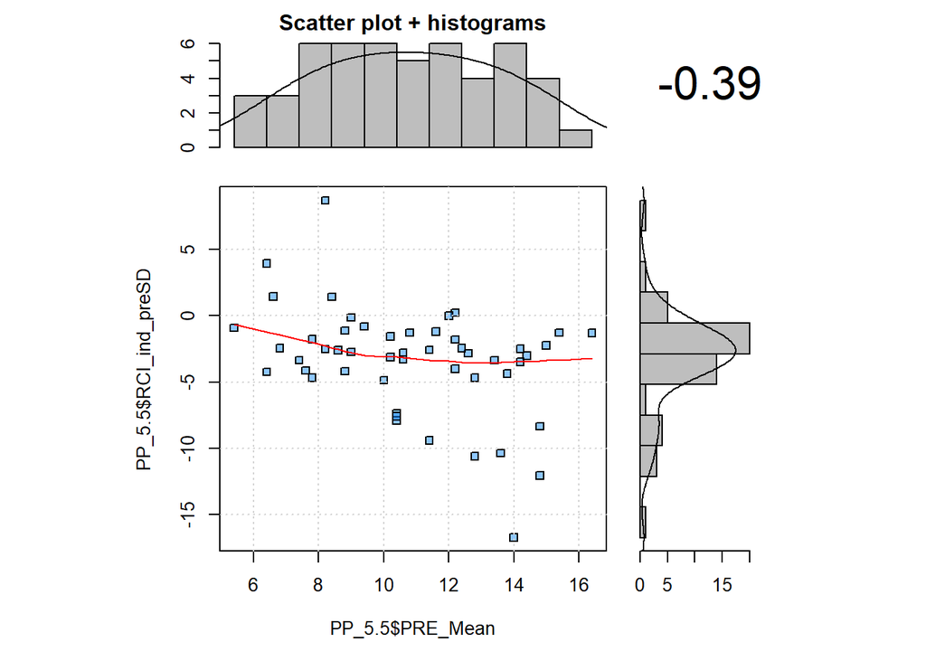

```r
PP_5.5$SEd_pre = sqrt(2 * (PP_5.5$ind.pretestSD * sqrt(1 - PP_5.5_Alpha)) ^ 2)
PP_5.5$RCI_ind_preSD = (PP_5.5$POST_Mean - PP_5.5$PRE_Mean) / PP_5.5$SEd_pre
PP_5.5$RCI_ind_preSD_Cutoff =  1.96 * PP_5.5$SEd_pre

# Sollen SEd_pre, RCI_ind_preSD und RCI_ind_preSD_Cutoff %in% c(-Inf,Inf) ein-/ausgeschlossen werden?
#PP_5.5 = PP_5.5 %>%
#  within(., {SEd_pre[SEd_pre %in% c(-Inf,Inf)] = NA
#               RCI_ind_preSD[RCI_ind_preSD %in% c(-Inf,Inf)] = NA
#               RCI_ind_preSD_Cutoff[RCI_ind_preSD_Cutoff %in% c(-Inf,Inf)] = NA})

scatter.hist(PP_5.5$PRE_Mean, PP_5.5$RCI_ind_preSD, xlab = "PP_5.5$PRE_Mean", ylab = "PP_5.5$RCI_ind_preSD", ellipse = FALSE, grid = TRUE, col = c("dodgerblue", "darkorange"))
```

Durchschnittlicher RCI(ind)-Cutoff für reliable Veränderung in PP_5.5 = 2.449.  
Korrelation RCI(ind) nur mit Pre-SD (je 5 MZP) mit PHQ-Baseline (Pre-Intervall-Mean) = -0.389.

> PP_30.30

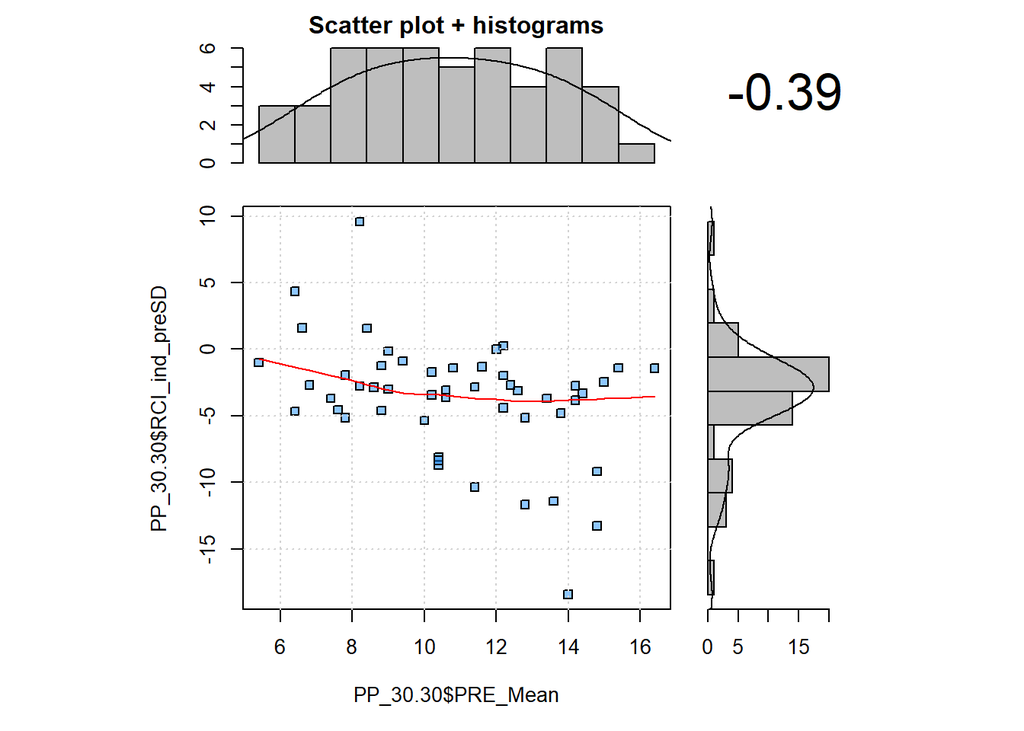

```r
PP_30.30$SEd_pre = sqrt(2 * (PP_30.30$ind.pretestSD * sqrt(1 - PP_5.5_Alpha)) ^ 2)
PP_30.30$RCI_ind_preSD = (PP_30.30$POST_Mean - PP_30.30$PRE_Mean) / PP_30.30$SEd_pre
PP_30.30$RCI_ind_preSD_Cutoff =  1.96 * PP_30.30$SEd_pre

# Sollen SEd_pre, RCI_ind_preSD und RCI_ind_preSD_Cutoff %in% c(-Inf,Inf) ein-/ausgeschlossen werden?
#PP_30.30 = PP_30.30 %>%
#  within(., {SEd_pre[SEd_pre %in% c(-Inf,Inf)] = NA
#               RCI_ind_preSD[RCI_ind_preSD %in% c(-Inf,Inf)] = NA
#               RCI_ind_preSD_Cutoff[RCI_ind_preSD_Cutoff %in% c(-Inf,Inf)] = NA})

scatter.hist(PP_30.30$PRE_Mean, PP_30.30$RCI_ind_preSD, xlab = "PP_30.30$PRE_Mean", ylab = "PP_30.30$RCI_ind_preSD", ellipse = FALSE, grid = TRUE, col = c("dodgerblue", "darkorange"))
```

Durchschnittlicher RCI(ind)-Cutoff für reliable Veränderung in PP_30.30 = 2.227.  
Korrelation RCI(ind) nur mit Pre-SD (je 30 MZP) mit PHQ-Baseline (Pre-Intervall-Mean) = -0.389.

### 1.9.2 RCI(ind) mit pooled SDs aus beiden individuellen Intervallen

$$RCI_{ind} = \frac{\overline{x_{2}} - \overline{x_{1}}} {SE_{D}}$$

$$SE_{D} = \sqrt{(s_{x}^2 + s_{y}^2) \cdot (1 - r_{xy})}$$

$$\text{significance cutoff} = 1.96 \cdot SE_{D} = 1.96 \cdot \sqrt{(s_{x}^2 + s_{y}^2) \cdot (1 - r_{xy})}$$

$\overline{x_{2}}$ = mean of subject´s posttest scores, $\overline{x_{1}}$ = mean of subject´s pretest scores, $SE_{D}$ = pooled standard error of difference between the test scores $s_{x}$ = individual standard deviation of pretest time points, $s_{y}$ = individual standard deviation of pretest time points, $r_{xy}$ = reliability (internal consistency Cronbach´s $\alpha$) of the measure, $\text{significance cutoff}$ = (absolute) cutoff score for reliable change (95%-criterion)

> PP_5.5

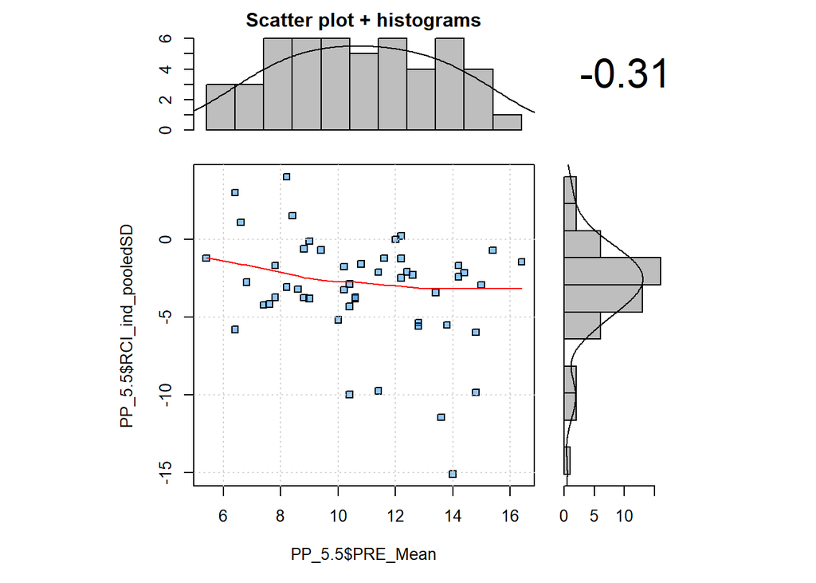

```r
PP_5.5$SEd_pooled = sqrt((PP_5.5$ind.pretestSD ^ 2 + PP_5.5$ind.posttestSD ^ 2) * (1 - PP_5.5_Alpha))
PP_5.5$RCI_ind_pooledSD = (PP_5.5$POST_Mean - PP_5.5$PRE_Mean) / PP_5.5$SEd_pooled
PP_5.5$RCI_ind_pooledSD_Cutoff =  1.96 * PP_5.5$SEd_pooled

# Sollen SEd_pooled, RCI_ind_pooledSD und RCI_ind_pooledSD_Cutoff %in% c(-Inf,Inf) ein-/ausgeschlossen werden?
#PP_5.5 = PP_5.5 %>%
#  within(., {SEd_pooled[SEd_pooled %in% c(-Inf,Inf)] = NA
#               RCI_ind_pooledSD[RCI_ind_pooledSD %in% c(-Inf,Inf)] = NA
#               RCI_ind_pooledSD_Cutoff[RCI_ind_pooledSD_Cutoff %in% c(-Inf,Inf)] = NA})

scatter.hist(PP_5.5$PRE_Mean, PP_5.5$RCI_ind_pooledSD, xlab = "PP_5.5$PRE_Mean", ylab = "PP_5.5$RCI_ind_pooledSD", ellipse = FALSE, grid = TRUE, col = c("dodgerblue", "darkorange"))
```

Durchschnittlicher RCI(ind)-Cutoff für reliable Veränderung in PP_5.5 = 2.676.  
Korrelation RCI(ind) mit pooled SDs (je 5 MZP) mit PHQ-Baseline (Pre-Intervall-Mean) = -0.313.

> PP_30.30

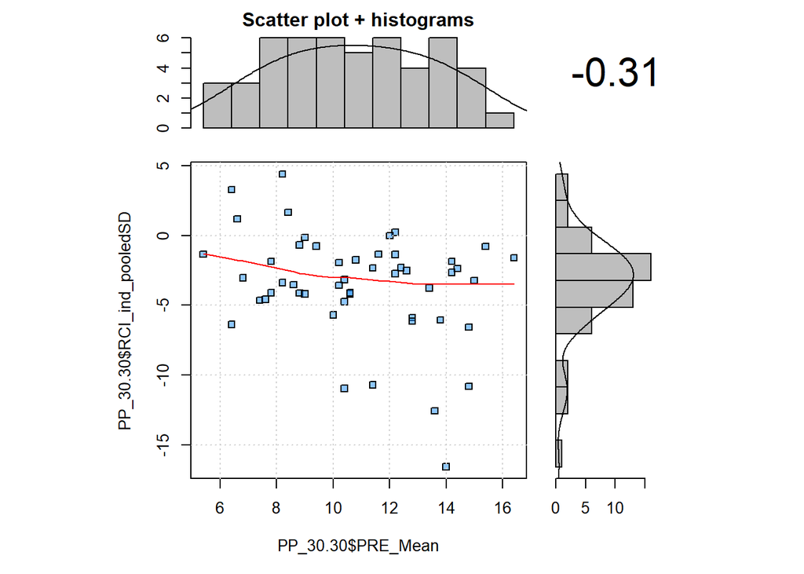

```r
PP_30.30$SEd_pooled = sqrt((PP_30.30$ind.pretestSD ^ 2 + PP_30.30$ind.posttestSD ^ 2) * (1 - PP_5.5_Alpha))
PP_30.30$RCI_ind_pooledSD = (PP_30.30$POST_Mean - PP_30.30$PRE_Mean) / PP_30.30$SEd_pooled
PP_30.30$RCI_ind_pooledSD_Cutoff =  1.96 * PP_30.30$SEd_pooled

# Sollen SEd_pooled, RCI_ind_pooledSD und RCI_ind_pooledSD_Cutoff %in% c(-Inf,Inf) ein-/ausgeschlossen werden?
#PP_30.30 = PP_30.30 %>%
#  within(., {SEd_pooled[SEd_pooled %in% c(-Inf,Inf)] = NA
#               RCI_ind_pooledSD[RCI_ind_pooledSD %in% c(-Inf,Inf)] = NA
#               RCI_ind_pooledSD_Cutoff[RCI_ind_pooledSD_Cutoff %in% c(-Inf,Inf)] = NA})

scatter.hist(PP_30.30$PRE_Mean, PP_30.30$RCI_ind_pooledSD, xlab = "PP_30.30$PRE_Mean", ylab = "PP_30.30$RCI_ind_pooledSD", ellipse = FALSE, grid = TRUE, col = c("dodgerblue", "darkorange"))
```

Durchschnittlicher RCI(ind)-Cutoff für reliable Veränderung in PP_30.30 = 2.434.  
Korrelation RCI(ind) mit pooled SDs (je 30 MZP) mit PHQ-Baseline (Pre-Intervall-Mean) = -0.313.

## 1.10 Vergleich RCI(JT) - RCI(ind)

> Vergleich des RCI(JT) in der Stichprobe mit je 1 MZP mit anderen RCIs (ind) in Intervall-Daten (je 5 MZP und je 30 MZP)

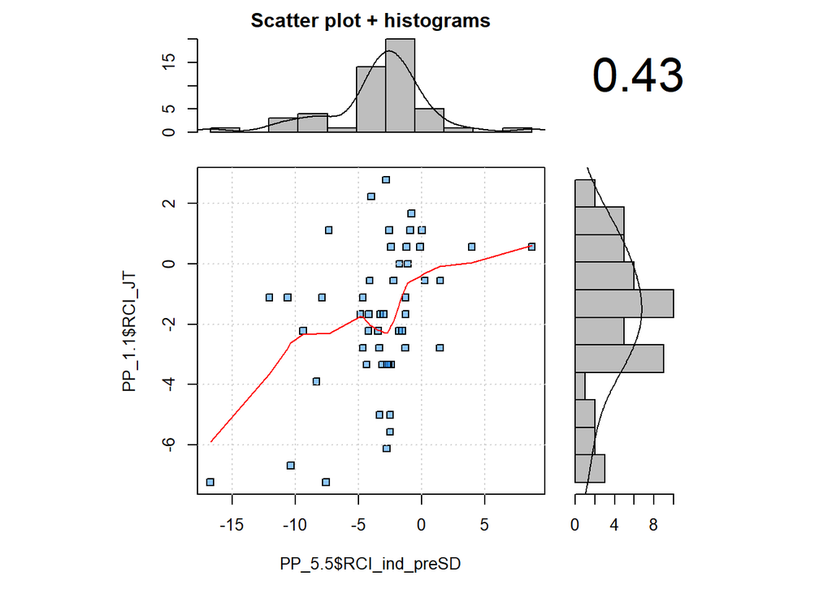

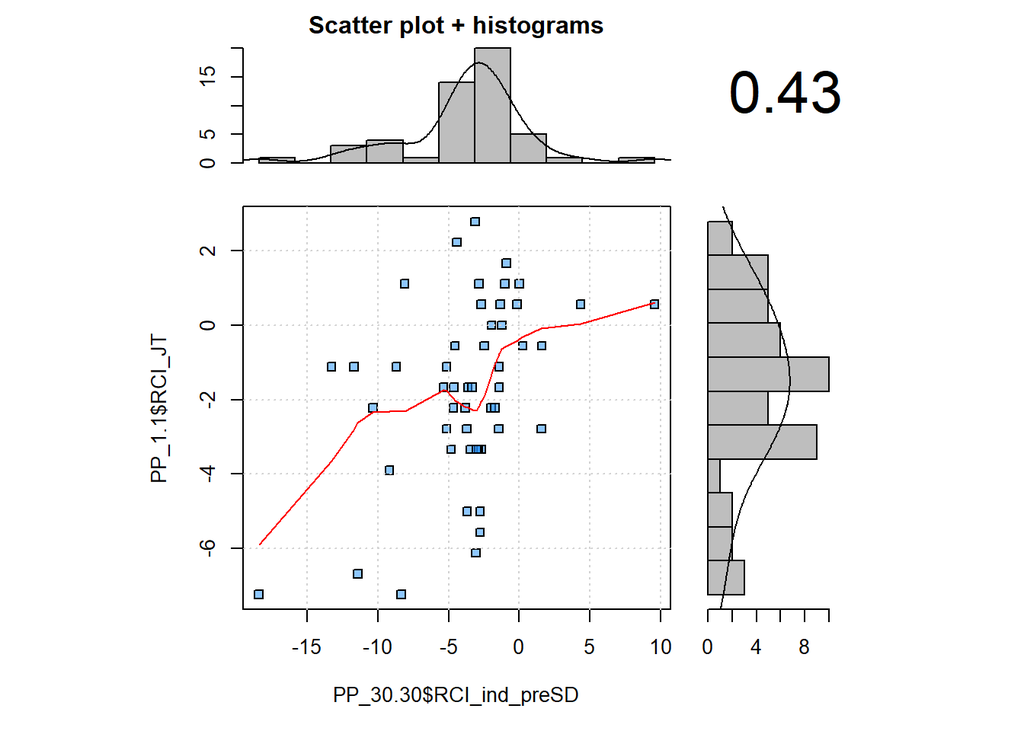

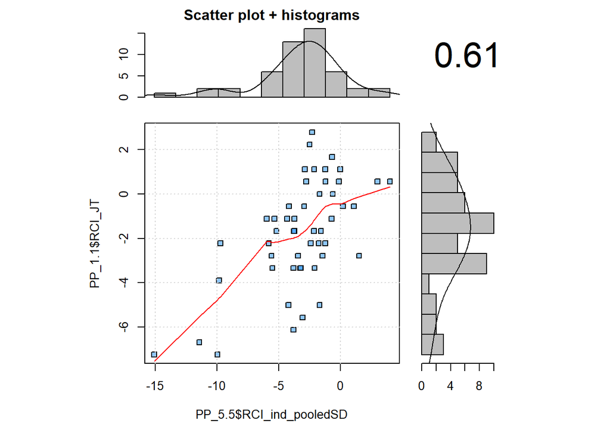

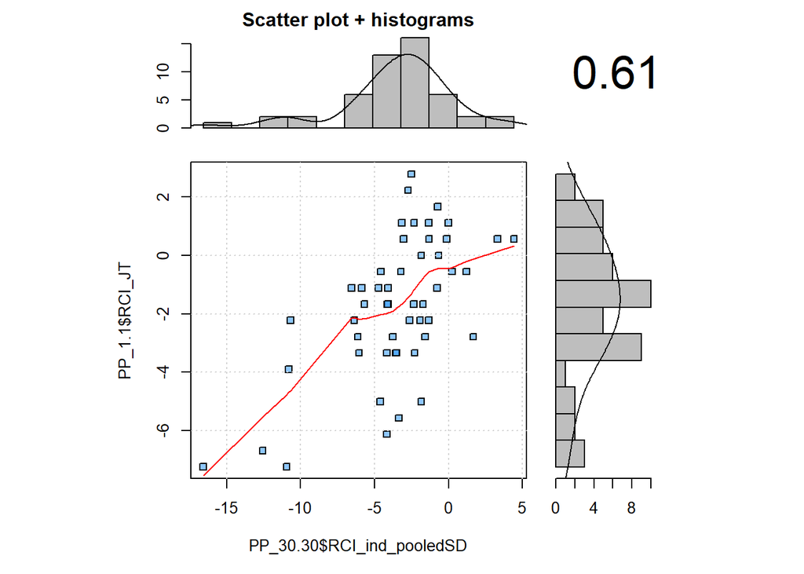

```r
x = PP_5.5 %>%
  within(., {RCI_ind_preSD[RCI_ind_preSD %in% c(-Inf,Inf)] = NA
         RCI_ind_pooledSD[RCI_ind_pooledSD %in% c(-Inf,Inf)] = NA})

y = PP_30.30 %>%
  within(., {RCI_ind_preSD[RCI_ind_preSD %in% c(-Inf,Inf)] = NA
         RCI_ind_pooledSD[RCI_ind_pooledSD %in% c(-Inf,Inf)] = NA})

z = PP_1.1 %>%
  within(., {RCI_JT[RCI_JT %in% c(-Inf,Inf)] = NA})

scatter.hist(x$RCI_ind_preSD, z$RCI_JT, xlab = "PP_5.5$RCI_ind_preSD", ylab = "PP_1.1$RCI_JT", ellipse =  FALSE, grid = TRUE, col = c("dodgerblue",  "darkorange"))

scatter.hist(y$RCI_ind_preSD, z$RCI_JT, xlab = "PP_30.30$RCI_ind_preSD", ylab = "PP_1.1$RCI_JT", ellipse =  FALSE, grid = TRUE, col = c("dodgerblue",  "darkorange"))

scatter.hist(x$RCI_ind_pooledSD, z$RCI_JT, xlab = "PP_5.5$RCI_ind_pooledSD", ylab = "PP_1.1$RCI_JT",  ellipse = FALSE, grid = TRUE, col = c("dodgerblue", "darkorange"))

scatter.hist(y$RCI_ind_pooledSD, z$RCI_JT, xlab = "PP_30.30$RCI_ind_pooledSD", ylab = "PP_1.1$RCI_JT",  ellipse = FALSE, grid = TRUE, col = c("dodgerblue", "darkorange"))
```

## 1.11 RCI-Klassifikationen

```r
RCI_Int = tibble(RCI = c("RCI < -1,96","-1,96 <= RCI <= 1,96","RCI > 1,96"),
                Klassifikation = c(-1,0,1),
                Interpretation = c("reliable Verbesserung","keine reliable Veränderung","reliable Verschlechterung"))
```

> PP_5.5: RCI(ind) nur mit Pre-SDs

```r
PP_5.5 = PP_5.5 %>%
  mutate(RCI_ind_preSD_klass = case_when(
    RCI_ind_preSD < -1.96 ~ -1,
    RCI_ind_preSD >= -1.96 & RCI_ind_preSD < 1.96 ~ 0,
    RCI_ind_preSD > 1.96 ~ 1,
    TRUE ~ RCI_ind_preSD
  )
)

temp = PP_5.5 %>%
  dplyr::count(RCI_ind_preSD_klass) %>%
  mutate(Percentage = round(((n / sum(n)) * 100), digits = 2))

RCI_Int %>%
  dplyr::rename(RCI_ind_preSD_klass = Klassifikation) %>%
  full_join(., temp) %>%
  kable() %>%
  kable_styling(bootstrap_options = c("striped", "hover", "condensed"), full_width = FALSE)
```

| RCI | RCI_ind_preSD_klass | Interpretation | n | Percentage |
| --- | --- | --- | --- | --- |
| RCI < -1,96 | -1 | reliable Verbesserung | 33 | 66 |
| -1,96 <= RCI <= 1,96 | 0 | keine reliable Veränderung | 15 | 30 |
| RCI > 1,96 | 1 | reliable Verschlechterung | 2 | 4 |

> PP_5.5: RCI(ind) mit pooled SDs

```r
PP_5.5 = PP_5.5 %>%
  mutate(RCI_ind_pooledSD_klass = case_when(
    RCI_ind_pooledSD < -1.96 ~ -1,
    RCI_ind_pooledSD >= -1.96 & RCI_ind_pooledSD < 1.96 ~ 0,
    RCI_ind_pooledSD > 1.96 ~ 1,
    TRUE ~ RCI_ind_pooledSD
  )
)

temp = PP_5.5 %>%
  dplyr::count(RCI_ind_pooledSD_klass) %>%
  mutate(Percentage = round(((n / sum(n)) * 100), digits = 2))

RCI_Int %>%
  dplyr::rename(RCI_ind_pooledSD_klass = Klassifikation) %>%
  full_join(., temp) %>%
  kable() %>%
  kable_styling(bootstrap_options = c("striped", "hover", "condensed"), full_width = FALSE)
```

| RCI | RCI_ind_pooledSD_klass | Interpretation | n | Percentage |
| --- | --- | --- | --- | --- |
| RCI < -1,96 | -1 | reliable Verbesserung | 32 | 64 |
| -1,96 <= RCI <= 1,96 | 0 | keine reliable Veränderung | 16 | 32 |
| RCI > 1,96 | 1 | reliable Verschlechterung | 2 | 4 |

> PP_30.30: RCI(ind) nur mit Pre-SDs

```r
PP_30.30 = PP_30.30 %>%
  mutate(RCI_ind_preSD_klass = case_when(
    RCI_ind_preSD < -1.96 ~ -1,
    RCI_ind_preSD >= -1.96 & RCI_ind_preSD < 1.96 ~ 0,
    RCI_ind_preSD > 1.96 ~ 1,
    TRUE ~ RCI_ind_preSD
  )
)

temp = PP_30.30 %>%
  dplyr::count(RCI_ind_preSD_klass) %>%
  mutate(Percentage = round(((n / sum(n)) * 100), digits = 2))

RCI_Int %>%
  dplyr::rename(RCI_ind_preSD_klass = Klassifikation) %>%
  full_join(., temp) %>%
  kable() %>%
  kable_styling(bootstrap_options = c("striped", "hover", "condensed"), full_width = FALSE)
```

| RCI | RCI_ind_preSD_klass | Interpretation | n | Percentage |
| --- | --- | --- | --- | --- |
| RCI < -1,96 | -1 | reliable Verbesserung | 34 | 68 |
| -1,96 <= RCI <= 1,96 | 0 | keine reliable Veränderung | 14 | 28 |
| RCI > 1,96 | 1 | reliable Verschlechterung | 2 | 4 |

> PP_30.30: RCI(ind) mit pooled SDs

```r
PP_30.30 = PP_30.30 %>%
  mutate(RCI_ind_pooledSD_klass = case_when(
    RCI_ind_pooledSD < -1.96 ~ -1,
    RCI_ind_pooledSD >= -1.96 & RCI_ind_pooledSD < 1.96 ~ 0,
    RCI_ind_pooledSD > 1.96 ~ 1,
    TRUE ~ RCI_ind_pooledSD
  )
)

temp = PP_30.30 %>%
  dplyr::count(RCI_ind_pooledSD_klass) %>%
  mutate(Percentage = round(((n / sum(n)) * 100), digits = 2))

RCI_Int %>%
  dplyr::rename(RCI_ind_pooledSD_klass = Klassifikation) %>%
  full_join(., temp) %>%
  kable() %>%
  kable_styling(bootstrap_options = c("striped", "hover", "condensed"), full_width = FALSE)
```

| RCI | RCI_ind_pooledSD_klass | Interpretation | n | Percentage |
| --- | --- | --- | --- | --- |
| RCI < -1,96 | -1 | reliable Verbesserung | 32 | 64 |
| -1,96 <= RCI <= 1,96 | 0 | keine reliable Veränderung | 16 | 32 |
| RCI > 1,96 | 1 | reliable Verschlechterung | 2 | 4 |

> PP_5.5: RCI(JT)-Zwischenstufe mit Pre-Mean - Post-Mean im Zähler.

```r
PP_5.5 = PP_5.5 %>%
  mutate(RCI_JT_ZwStufe_klass = case_when(
    RCI_JT_ZwStufe < -1.96 ~ -1,
    RCI_JT_ZwStufe >= -1.96 & RCI_JT_ZwStufe < 1.96 ~ 0,
    RCI_JT_ZwStufe > 1.96 ~ 1,
    TRUE ~ RCI_JT_ZwStufe
  )
)

temp = PP_5.5 %>%
  dplyr::count(RCI_JT_ZwStufe_klass) %>%
  mutate(Percentage = round(((n / sum(n)) * 100), digits = 2))

RCI_Int %>%
  dplyr::rename(RCI_JT_ZwStufe_klass = Klassifikation) %>%
  full_join(., temp) %>%
  kable() %>%
  kable_styling(bootstrap_options = c("striped", "hover", "condensed"), full_width = FALSE)
```

| RCI | RCI_JT_ZwStufe_klass | Interpretation | n | Percentage |
| --- | --- | --- | --- | --- |
| RCI < -1,96 | -1 | reliable Verbesserung | 29 | 58 |
| -1,96 <= RCI <= 1,96 | 0 | keine reliable Veränderung | 19 | 38 |
| RCI > 1,96 | 1 | reliable Verschlechterung | 2 | 4 |

> PP_1.1: RCI(JT)

```r
PP_1.1 = PP_1.1 %>%
  mutate(RCI_JT_klass = case_when(
    RCI_JT < -1.96 ~ -1,
    RCI_JT >= -1.96 & RCI_JT < 1.96 ~ 0,
    RCI_JT > 1.96 ~ 1,
    TRUE ~ RCI_JT
  )
)

temp = PP_1.1 %>%
  dplyr::count(RCI_JT_klass) %>%
  mutate(Percentage = round(((n / sum(n)) * 100), digits = 2))

RCI_Int %>%
  dplyr::rename(RCI_JT_klass = Klassifikation) %>%
  full_join(., temp) %>%
  kable() %>%
  kable_styling(bootstrap_options = c("striped", "hover", "condensed"), full_width = FALSE)
```

| RCI | RCI_JT_klass | Interpretation | n | Percentage |
| --- | --- | --- | --- | --- |
| RCI < -1,96 | -1 | reliable Verbesserung | 22 | 44 |
| -1,96 <= RCI <= 1,96 | 0 | keine reliable Veränderung | 26 | 52 |
| RCI > 1,96 | 1 | reliable Verschlechterung | 2 | 4 |

## 1.12 Edwards-Nunnally-Methode (EN) nach Speer (1992)

$$\bigl[ r_{xx} (X_{pre} - M_{pre}) + M_{pre} \bigr] \pm 2 \cdot S_{pre} \cdot \sqrt{1 - r_{xx}}$$

$r_{xx}$ = reliability of the measure, $X_{pre}$ = individual´s raw score at pre-treatment, $M_{pre}$ = mean of the sample at pre-treatment, $S_{pre}$ = standard deviation of the sample at pre-treatment

> Interpretation der Post-Ausprägung nach EN-Intervall-Methode

```r
EN_Int = tibble(EN = c("PHQ POST < [EN-Intervall]","PHQ POST im [EN-Intervall]","PHQ POST > [EN-Intervall]"),
                Klassifikation = c(-1,0,1), Interpretation = c("signifikante Verbesserung",
                        "keine signifikante Veränderung","signifikante Verschlechterung"))
```

> EN-Intervalle in PP_5.5

```r
PP_5.5$EN_min = (PP_5.5_Alpha * (PP_5.5$PRE_Mean - mean(PP_5.5$PRE_Mean)) + mean(PP_5.5$PRE_Mean)) - 2 *
  mean(PP_5.5$ind.pretestSD) * sqrt(1 - PP_5.5_Alpha)

PP_5.5$EN_max = (PP_5.5_Alpha * (PP_5.5$PRE_Mean - mean(PP_5.5$PRE_Mean)) + mean(PP_5.5$PRE_Mean)) + 2 *
  mean(PP_5.5$ind.pretestSD) * sqrt(1 - PP_5.5_Alpha)

PP_5.5 = PP_5.5 %>%
  mutate(EN_klass = case_when(
    POST_Mean > EN_max ~ 1,
    POST_Mean < EN_max & POST_Mean > EN_min ~ 0,
    POST_Mean < EN_min ~ -1,
    TRUE ~ POST_Mean
  )
)

temp = PP_5.5 %>%
  dplyr::count(EN_klass) %>%
  mutate(Percentage = round(((n / sum(n)) * 100), digits = 2))

EN_Int %>%
  dplyr::rename(EN_klass = Klassifikation) %>%
  full_join(., temp) %>%
  kable() %>%
  kable_styling(bootstrap_options = c("striped", "hover", "condensed"), full_width = FALSE)
```

| EN | EN_klass | Interpretation | n | Percentage |
| --- | --- | --- | --- | --- |
| PHQ POST < [EN-Intervall] | -1 | signifikante Verbesserung | 38 | 76 |
| PHQ POST im [EN-Intervall] | 0 | keine signifikante Veränderung | 10 | 20 |
| PHQ POST > [EN-Intervall] | 1 | signifikante Verschlechterung | 2 | 4 |

> EN-Intervalle in PP_30.30

```r
PP_30.30$EN_min = (PP_5.5_Alpha * (PP_30.30$PRE_Mean - mean(PP_30.30$PRE_Mean)) + mean(PP_30.30$PRE_Mean)) - 2 * mean(PP_30.30$ind.pretestSD) * sqrt(1 - PP_5.5_Alpha)

PP_30.30$EN_max = (PP_5.5_Alpha * (PP_30.30$PRE_Mean - mean(PP_30.30$PRE_Mean)) + mean(PP_30.30$PRE_Mean)) + 2 * mean(PP_30.30$ind.pretestSD) * sqrt(1 - PP_5.5_Alpha)

PP_30.30 = PP_30.30 %>%
  mutate(EN_klass = case_when(
    POST_Mean > EN_max ~ 1,
    POST_Mean < EN_max & POST_Mean > EN_min ~ 0,
    POST_Mean < EN_min ~ -1,
    TRUE ~ POST_Mean
  )
)

temp = PP_30.30 %>%
  dplyr::count(EN_klass) %>%
  mutate(Percentage = round(((n / sum(n)) * 100), digits = 2))

EN_Int %>%
  dplyr::rename(EN_klass = Klassifikation) %>%
  full_join(., temp) %>%
  kable() %>%
  kable_styling(bootstrap_options = c("striped", "hover", "condensed"), full_width = FALSE)
```

| EN | EN_klass | Interpretation | n | Percentage |
| --- | --- | --- | --- | --- |
| PHQ POST < [EN-Intervall] | -1 | signifikante Verbesserung | 38 | 76 |
| PHQ POST im [EN-Intervall] | 0 | keine signifikante Veränderung | 10 | 20 |
| PHQ POST > [EN-Intervall] | 1 | signifikante Verschlechterung | 2 | 4 |

> EN-Intervalle in PP_1.1

```r
PP_1.1$EN_min = (PP_5.5_Alpha * (PP_1.1$PRE - mean(PP_1.1$PRE)) + mean(PP_1.1$PRE)) - 2 * sd(PP_1.1$PRE) * sqrt(1 - PP_5.5_Alpha)

PP_1.1$EN_max = (PP_5.5_Alpha * (PP_1.1$PRE - mean(PP_1.1$PRE)) + mean(PP_1.1$PRE)) + 2 * sd(PP_1.1$PRE) * sqrt(1 - PP_5.5_Alpha)

PP_1.1 = PP_1.1 %>%
  mutate(EN_klass = case_when(
    POST > EN_max ~ 1,
    POST < EN_max & POST > EN_min ~ 0,
    POST < EN_min ~ -1,
    TRUE ~ as.numeric(POST)
  )
)

temp = PP_1.1 %>%
  dplyr::count(EN_klass) %>%
  mutate(Percentage = round(((n / sum(n)) * 100), digits = 2))

EN_Int %>%
  dplyr::rename(EN_klass = Klassifikation) %>%
  full_join(., temp) %>%
  kable() %>%
  kable_styling(bootstrap_options = c("striped", "hover", "condensed"), full_width = FALSE)
```

| EN | EN_klass | Interpretation | n | Percentage |
| --- | --- | --- | --- | --- |
| PHQ POST < [EN-Intervall] | -1 | signifikante Verbesserung | 27 | 54 |
| PHQ POST im [EN-Intervall] | 0 | keine signifikante Veränderung | 21 | 42 |
| PHQ POST > [EN-Intervall] | 1 | signifikante Verschlechterung | 2 | 4 |

## 1.13 Clinically Significant Improvement (CSI)

> Clinically Significant Improvement (CSI) vom Pre- zum Post-Intervall

> “The original validation study of the PHQ-9 defined clinically significant improvement as [a pre-treatment score >= 10 and] a post-treatment score of <= 9 combined with improvement of 50%.” (McMillan, Gilbody, & Richards, 2010)

```r
CSI_Int = tibble(CSI = c("Pre-Score >= 10 & Post-Score <= 9 & PC >= 50", "every other combination",
                         "Pre-Score <= 9 & Post-Score >= 10 & PC <= -50"),
                Klassifikation = c(-1,0,1),
                Interpretation = c("klinisch signifikante Verbesserung", "keine klinisch signifikante Veränderung",
                                   "klinisch signifikante Verschlechterung"))
```

### 1.13.1 CSI in PP_5.5

```r
PP_5.5 = PP_5.5 %>%
   mutate(CSI_klass = case_when(
     PRE_Mean >= 10 & POST_Mean <= 9 & Mean_PC >= 50 ~ -1,
     PRE_Mean <= 9 & POST_Mean >= 10 & Mean_PC <= -50 ~ 1,
     TRUE ~ 0
   )
)

temp = PP_5.5 %>%
  dplyr::count(CSI_klass) %>%
  mutate(Percentage = round(((n / sum(n)) * 100), digits = 2))

CSI_Int %>%
  dplyr::rename(CSI_klass = Klassifikation) %>%
  full_join(., temp) %>%
  kable() %>%
  kable_styling(bootstrap_options = c("striped", "hover", "condensed"), full_width = FALSE)
```

| CSI | CSI_klass | Interpretation | n | Percentage |
| --- | --- | --- | --- | --- |
| Pre-Score >= 10 & Post-Score <= 9 & PC >= 50 | -1 | klinisch signifikante Verbesserung | 9 | 18 |
| every other combination | 0 | keine klinisch signifikante Veränderung | 39 | 78 |
| Pre-Score <= 9 & Post-Score >= 10 & PC <= -50 | 1 | klinisch signifikante Verschlechterung | 2 | 4 |

### 1.13.2 CSI in PP_30.30

```r
PP_30.30 = PP_30.30 %>%
   mutate(CSI_klass = case_when(
     PRE_Mean >= 10 & POST_Mean <= 9 & Mean_PC >= 50 ~ -1,
     PRE_Mean <= 9 & POST_Mean >= 10 & Mean_PC <= -50 ~ 1,
     TRUE ~ 0
   )
)

temp = PP_30.30 %>%
  dplyr::count(CSI_klass) %>%
  mutate(Percentage = round(((n / sum(n)) * 100), digits = 2))

CSI_Int %>%
  dplyr::rename(CSI_klass = Klassifikation) %>%
  full_join(., temp) %>%
  kable() %>%
  kable_styling(bootstrap_options = c("striped", "hover", "condensed"), full_width = FALSE)
```

| CSI | CSI_klass | Interpretation | n | Percentage |
| --- | --- | --- | --- | --- |
| Pre-Score >= 10 & Post-Score <= 9 & PC >= 50 | -1 | klinisch signifikante Verbesserung | 9 | 18 |
| every other combination | 0 | keine klinisch signifikante Veränderung | 39 | 78 |
| Pre-Score <= 9 & Post-Score >= 10 & PC <= -50 | 1 | klinisch signifikante Verschlechterung | 2 | 4 |

### 1.13.3 CSI in PP_1.1

```r
PP_1.1 = PP_1.1 %>%
   mutate(CSI_klass = case_when(
     PRE >= 10 & POST <= 9 & PC >= 50 ~ -1,
     PRE <= 9 & POST >= 10 & PC <= -50 ~ 1,
     TRUE ~ 0
   )
)

temp = PP_1.1 %>%
  dplyr::count(CSI_klass) %>%
  mutate(Percentage = round(((n / sum(n)) * 100), digits = 2))

CSI_Int %>%
  dplyr::rename(CSI_klass = Klassifikation) %>%
  full_join(., temp) %>%
  kable() %>%
  kable_styling(bootstrap_options = c("striped", "hover", "condensed"), full_width = FALSE)
```

| CSI | CSI_klass | Interpretation | n | Percentage |
| --- | --- | --- | --- | --- |
| Pre-Score >= 10 & Post-Score <= 9 & PC >= 50 | -1 | klinisch signifikante Verbesserung | 10 | 20 |
| every other combination | 0 | keine klinisch signifikante Veränderung | 39 | 78 |
| Pre-Score <= 9 & Post-Score >= 10 & PC <= -50 | 1 | klinisch signifikante Verschlechterung | 1 | 2 |

## 1.14 Individuelle Übereinstimmung der Klassifikationen

> Übereinstimmung der Klassifikationen auf individueller Ebene zwischen PP_5.5, PP_30.30 und PP_1.1:

> Interpretation von Cohen´s Kappa:

```r
tibble(Cohen_Kappa = c("k < .20",".21 <= k < .40",".41 <= k < .60",".61 <= k < .80","k > .80"),
       Interpretation = c("poor","fair","moderate","good","very good")) %>%
  kable() %>%
  kable_styling(bootstrap_options = c("striped", "hover", "condensed"), full_width = FALSE)
```

| Cohen_Kappa | Interpretation |
| --- | --- |
| k < .20 | poor |
| .21 <= k < .40 | fair |
| .41 <= k < .60 | moderate |
| .61 <= k < .80 | good |
| k > .80 | very good |

### 1.14.1 Klinische PHQ-9-Interpretation

> Übereinstimmung zwischen den klinischen Interpretationen der PHQ-9-Werte für Pre- und Post-Intervalle (je 5 MZP und je 30 MZP) und für einzelne Pre- und Post-Messzeitpunkte (je 1 MZP):

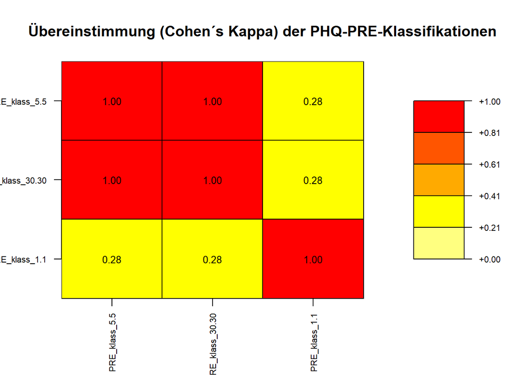

```r
# PRE
x = PP_5.5 %>%
  select(ID, PRE_Mean_klass) %>%
  dplyr::rename(PRE_klass.5 = PRE_Mean_klass)

y = PP_30.30 %>%
  select(ID, PRE_Mean_klass) %>%
  dplyr::rename(PRE_klass.30 = PRE_Mean_klass)

z = PP_1.1 %>%
  select(ID, PRE_klass) %>%
  dplyr::rename(PRE_klass.1 = PRE_klass)

temp = full_join(x, y, by = "ID") %>%
  full_join(., z, by = "ID") %>%
  select(-ID) %>%
  mutate(across(.cols = everything(), as.factor))

### Cohen´s Kappa
rnames = c("PRE_klass_5.5", "PRE_klass_30.30", "PRE_klass_1.1")

Agreement = matrix(ncol = 3, nrow = 3, dimnames = list(rnames, rnames))

for (i in 1:nrow(Agreement)) {
  for (j in 1:ncol(Agreement)) {
    x = eval(parse(text = paste0("temp$", names(temp[,i]))))
    y = eval(parse(text = paste0("temp$", names(temp[,j]))))

    Agreement[i,j] = CohenKappa(x = x, y = y)
  }
}

# mit plot.matrix::...
par(mar = c(5.1, 4.1, 4.1, 4.1)) # default c(5.1, 4.1, 4.1, 2.1)
plot(Agreement, col = heat.colors(n=5, rev=TRUE), fmt.cell = "%.2f", cex.axis = 0.7, cex = 0.8, las = 2,
     key = list(cex.axis=0.7), ann = FALSE, breaks = c(0, 0.21, 0.41, 0.61, 0.81, 1));
  title(main = "Übereinstimmung (Cohen´s Kappa) der PHQ-PRE-Klassifikationen")
```

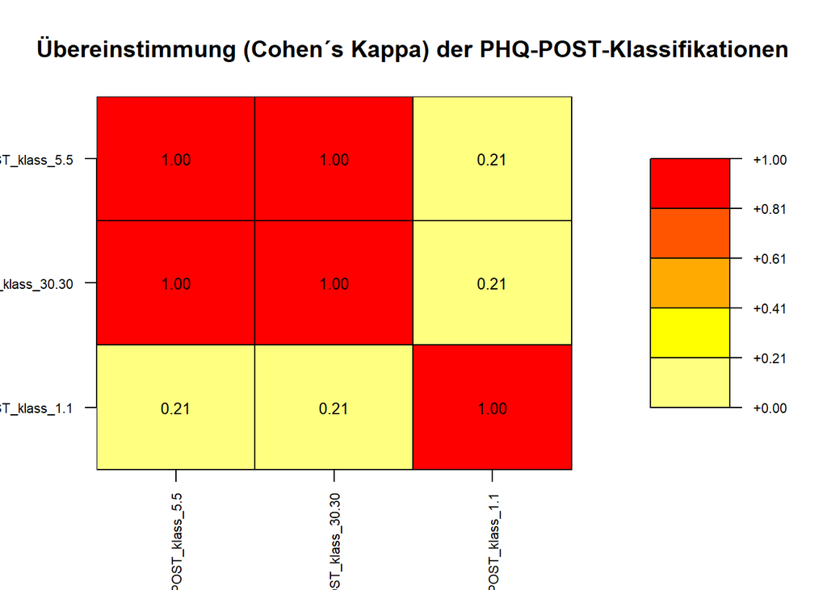

```r
# POST
x = PP_5.5 %>%
  select(ID, POST_Mean_klass) %>%
  dplyr::rename(POST_klass.5 = POST_Mean_klass)

y = PP_30.30 %>%
  select(ID, POST_Mean_klass) %>%
  dplyr::rename(POST_klass.30 = POST_Mean_klass)

z = PP_1.1 %>%
  select(ID, POST_klass) %>%
  dplyr::rename(POST_klass.1 = POST_klass)

temp = full_join(x, y, by = "ID") %>%
  full_join(., z, by = "ID") %>%
  select(-ID) %>%
  mutate(across(.cols = everything(), as.factor))

### Cohen´s Kappa
rnames = c("POST_klass_5.5", "POST_klass_30.30", "POST_klass_1.1")

Agreement = matrix(ncol = 3, nrow = 3, dimnames = list(rnames, rnames))

for (i in 1:nrow(Agreement)) {
  for (j in 1:ncol(Agreement)) {
    x = eval(parse(text = paste0("temp$", names(temp[,i]))))
    y = eval(parse(text = paste0("temp$", names(temp[,j]))))

    Agreement[i,j] = CohenKappa(x = x, y = y)
  }
}

# mit plot.matrix::...
par(mar = c(5.1, 4.1, 4.1, 4.1)) # default c(5.1, 4.1, 4.1, 2.1)
plot(Agreement, col = heat.colors(n=5, rev=TRUE), fmt.cell = "%.2f", cex.axis = 0.7, cex = 0.8, las = 2,
     key = list(cex.axis=0.7), ann = FALSE, breaks = c(0, 0.21, 0.41, 0.61, 0.81, 1));
  title(main = "Übereinstimmung (Cohen´s Kappa) der PHQ-POST-Klassifikationen")
```

### 1.14.2 Zusammenfassung der Klassifikations-Häufigkeiten

```r
# einheitliche Kodierung von Verbesserung (-1), keiner Veränderung (0) und Verschlechterung (1):

x = PP_5.5 %>%
  select(ID, Mean_PC_klass, RCI_ind_preSD_klass, RCI_ind_pooledSD_klass, RCI_JT_ZwStufe_klass, EN_klass, CSI_klass) %>%
  dplyr::rename(Mean_PC_5.5 = Mean_PC_klass, RCI_ind_preSD_5.5 = RCI_ind_preSD_klass, RCI_ind_pooledSD_5.5 = RCI_ind_pooledSD_klass,
         RCI_JT_ZwStufe_5.5 = RCI_JT_ZwStufe_klass, EN_5.5 = EN_klass, CSI_5.5 = CSI_klass) %>%
  mutate(Mean_PC_5.5 = recode(Mean_PC_5.5, '-2' = 1L, '-1' = 0L, '0' = 0L, '1' = 0L, '2' = -1L))

y = PP_30.30 %>%
  select(ID, Mean_PC_klass, RCI_ind_preSD_klass, RCI_ind_pooledSD_klass, EN_klass, CSI_klass) %>%
  dplyr::rename(Mean_PC_30.30 = Mean_PC_klass, RCI_ind_preSD_30.30 = RCI_ind_preSD_klass,
         RCI_ind_pooledSD_30.30 = RCI_ind_pooledSD_klass, EN_30.30 = EN_klass, CSI_30.30 = CSI_klass) %>%
  mutate(Mean_PC_30.30 = recode(Mean_PC_30.30, '-2' = 1L, '-1' = 0L, '0' = 0L, '1' = 0L, '2' = -1L))

z = PP_1.1 %>%
  select(ID, PC_klass, RCI_JT_klass, EN_klass, CSI_klass) %>%
  dplyr::rename(PC_1.1 = PC_klass, RCI_JT_1.1 = RCI_JT_klass,
         EN_1.1 = EN_klass, CSI_1.1 = CSI_klass) %>%
  mutate(PC_1.1 = recode(PC_1.1, '-2' = 1L, '-1' = 0L, '0' = 0L, '1' = 0L, '2' = -1L))

PP_Class = full_join(x, y, by = "ID") %>%
  full_join(., z, "ID") %>%
  select(-ID) %>%
  dplyr::mutate(across(.cols = everything(), as.factor))
#save(PP_Class, file = "cor_07_k20/PP_Class_n50.RData")

rnames = names(PP_Class)


#view(dfSummary(PP_Class))
#dfSummary(PP_Class, plain.ascii = FALSE, style = 'grid', graph.magnif = 0.75, valid.col = FALSE, tmp.img.dir = "/tmp")
#dfSummary(PP_Class)
print(dfSummary(PP_Class, varnumbers = FALSE, plain.ascii = FALSE, style = 'grid', graph.magnif = 0.75, valid.col = FALSE, na.col = FALSE, display.labels = FALSE, silent = FALSE, headers = FALSE, footnote = NA, tmp.img.dir = "/tmp"), method = 'render')
```

Data Frame Summary

PP_Class

**Dimensions**: 50 x 15  
**Duplicates**: 22

| **Variable** | **Stats / Values** | **Freqs (% of Valid)** | **Graph** |
| --- | --- | --- | --- |
| Mean_PC_5.5 [factor] | 1. -1 2. 0 3. 1 | 15 ( 30.0% ) 33 ( 66.0% ) 2 ( 4.0% ) |  |
| RCI_ind_preSD_5.5 [factor] | 1. -1 2. 0 3. 1 | 33 ( 66.0% ) 15 ( 30.0% ) 2 ( 4.0% ) |  |
| RCI_ind_pooledSD_5.5 [factor] | 1. -1 2. 0 3. 1 | 32 ( 64.0% ) 16 ( 32.0% ) 2 ( 4.0% ) |  |
| RCI_JT_ZwStufe_5.5 [factor] | 1. -1 2. 0 3. 1 | 29 ( 58.0% ) 19 ( 38.0% ) 2 ( 4.0% ) |  |
| EN_5.5 [factor] | 1. -1 2. 0 3. 1 | 38 ( 76.0% ) 10 ( 20.0% ) 2 ( 4.0% ) |  |
| CSI_5.5 [factor] | 1. -1 2. 0 3. 1 | 9 ( 18.0% ) 39 ( 78.0% ) 2 ( 4.0% ) |  |
| Mean_PC_30.30 [factor] | 1. -1 2. 0 3. 1 | 15 ( 30.0% ) 33 ( 66.0% ) 2 ( 4.0% ) |  |
| RCI_ind_preSD_30.30 [factor] | 1. -1 2. 0 3. 1 | 34 ( 68.0% ) 14 ( 28.0% ) 2 ( 4.0% ) |  |
| RCI_ind_pooledSD_30.30 [factor] | 1. -1 2. 0 3. 1 | 32 ( 64.0% ) 16 ( 32.0% ) 2 ( 4.0% ) |  |
| EN_30.30 [factor] | 1. -1 2. 0 3. 1 | 38 ( 76.0% ) 10 ( 20.0% ) 2 ( 4.0% ) |  |
| CSI_30.30 [factor] | 1. -1 2. 0 3. 1 | 9 ( 18.0% ) 39 ( 78.0% ) 2 ( 4.0% ) |  |
| PC_1.1 [factor] | 1. -1 2. 0 3. 1 | 14 ( 28.0% ) 33 ( 66.0% ) 3 ( 6.0% ) |  |
| RCI_JT_1.1 [factor] | 1. -1 2. 0 3. 1 | 22 ( 44.0% ) 26 ( 52.0% ) 2 ( 4.0% ) |  |
| EN_1.1 [factor] | 1. -1 2. 0 3. 1 | 27 ( 54.0% ) 21 ( 42.0% ) 2 ( 4.0% ) |  |
| CSI_1.1 [factor] | 1. -1 2. 0 3. 1 | 10 ( 20.0% ) 39 ( 78.0% ) 1 ( 2.0% ) |  |

Generated by summarytools 0.9.6 ([R](https://www.r-project.org/) version 4.0.2)  
2020-12-13

### 1.14.3 Übereinstimmung der Klassifikations-Häufigkeiten

> Gesamt-Übereinstimmung

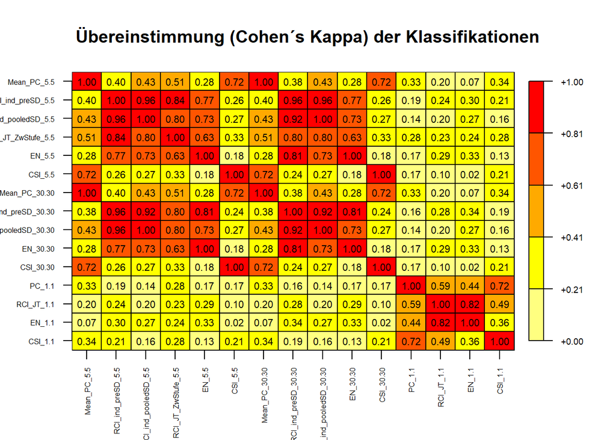

```r
### Cohen´s Kappa
Agreement = matrix(ncol = 15, nrow = 15, dimnames = list(rnames, rnames))

for (i in 1:nrow(Agreement)) {
  for (j in 1:ncol(Agreement)) {
    x = eval(parse(text = paste0("PP_Class$", names(PP_Class[,i]))))
    y = eval(parse(text = paste0("PP_Class$", names(PP_Class[,j]))))

    Agreement[i,j] = CohenKappa(x = x, y = y)
  }
}

# mit plot.matrix::...
par(mar = c(5.1, 4.1, 4.1, 4.1)) # default c(5.1, 4.1, 4.1, 2.1)
plot(Agreement, col = heat.colors(n=5, rev=TRUE), fmt.cell = "%.2f", cex.axis = 0.5, cex = 0.7, las = 2,
     key = list(cex.axis=0.6), ann = FALSE, breaks = c(0, 0.21, 0.41, 0.61, 0.81, 1));
  title(main = "Übereinstimmung (Cohen´s Kappa) der Klassifikationen")
```

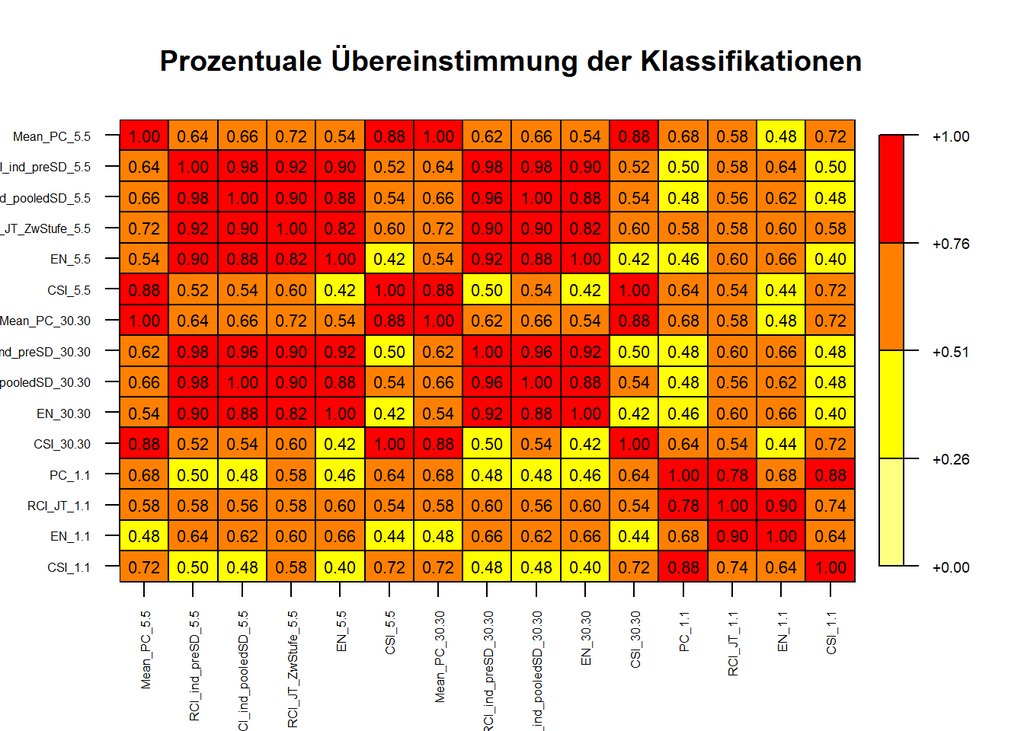

```r
### Prozentuale Übereinstimmung
Percentage_Agreement = matrix(ncol = 15, nrow = 15, dimnames = list(rnames, rnames))

for (i in 1:nrow(Percentage_Agreement)) {
  for (j in 1:ncol(Percentage_Agreement)) {
    x = eval(parse(text = paste0("PP_Class$", names(PP_Class[,i]))))
    y = eval(parse(text = paste0("PP_Class$", names(PP_Class[,j]))))

    Percentage_Agreement[i,j] = Agree(cbind(x, y))[1]
  }
}

# mit plot.matrix::...
par(mar = c(5.1, 4.1, 4.1, 4.1)) # default c(5.1, 4.1, 4.1, 2.1)
plot(Percentage_Agreement, col = heat.colors(n=4, rev=TRUE), fmt.cell = "%.2f", cex.axis = 0.5, cex = 0.7, las = 2,
     key = list(cex.axis=0.6), ann = FALSE, breaks = c(0, 0.26, 0.51, 0.76, 1));
  title(main = "Prozentuale Übereinstimmung der Klassifikationen")
```

> Übereinstimmung nur für Verbesserung (-1)

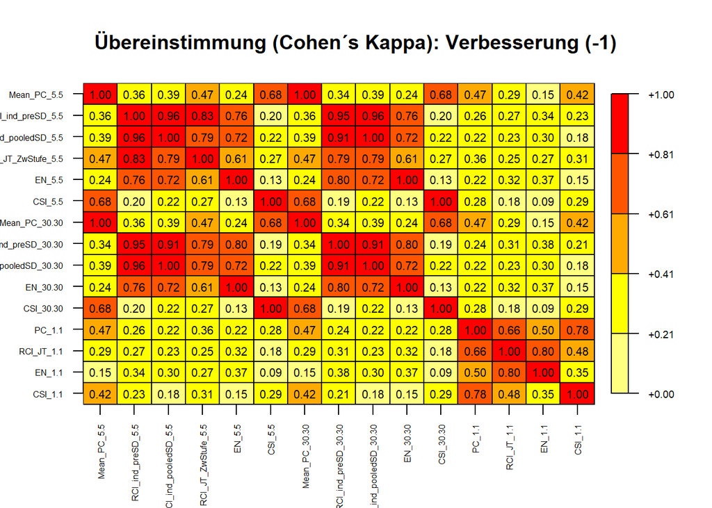

```r
### Cohen´s Kappa
Agreement = matrix(ncol = 15, nrow = 15, dimnames = list(rnames, rnames))

for (i in 1:nrow(Agreement)) {
  for (j in 1:ncol(Agreement)) {
    x = eval(parse(text = paste0("PP_Class$", names(PP_Class[,i])))) %>%
      dplyr::recode_factor(., '-1' = -1L)
    y = eval(parse(text = paste0("PP_Class$", names(PP_Class[,j])))) %>%
      dplyr::recode_factor(., '-1' = -1L)

    Agreement[i,j] = CohenKappa(x = x, y = y, useNA = "ifany")
  }
}

# mit plot.matrix::...
par(mar = c(5.1, 4.1, 4.1, 4.1)) # default c(5.1, 4.1, 4.1, 2.1)
plot(Agreement, col = heat.colors(n=5, rev=TRUE), fmt.cell = "%.2f", cex.axis = 0.5, cex = 0.7, las = 2,
     key = list(cex.axis=0.6), ann = FALSE, breaks = c(0, 0.21, 0.41, 0.61, 0.81, 1));
  title(main = "Übereinstimmung (Cohen´s Kappa): Verbesserung (-1)")
```

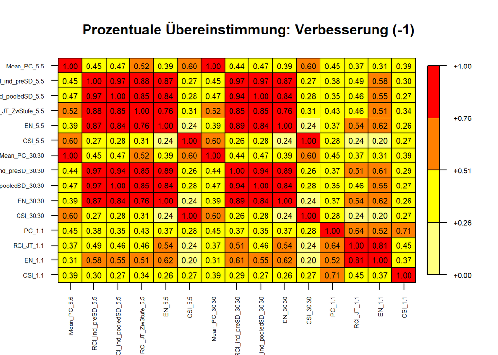

```r
### Prozentuale Übereinstimmung
Percentage_Agreement = matrix(ncol = 15, nrow = 15, dimnames = list(rnames, rnames))

for (i in 1:nrow(Percentage_Agreement)) {
  for (j in 1:ncol(Percentage_Agreement)) {
    x = eval(parse(text = paste0("PP_Class$", names(PP_Class[,i]))))
    y = eval(parse(text = paste0("PP_Class$", names(PP_Class[,j]))))

    Percentage_Agreement[i,j] = length(which(x == -1L & y == -1L)) /
      length(which(x == -1L | y == -1L))
  }
}

# mit plot.matrix::...
par(mar = c(5.1, 4.1, 4.1, 4.1)) # default c(5.1, 4.1, 4.1, 2.1)
plot(Percentage_Agreement, col = heat.colors(n=4, rev=TRUE), fmt.cell = "%.2f", cex.axis = 0.5, cex = 0.7, las = 2,
     key = list(cex.axis=0.6), ann = FALSE, breaks = c(0, 0.26, 0.51, 0.76, 1));
  title(main = "Prozentuale Übereinstimmung: Verbesserung (-1)")
```

> Übereinstimmung nur für Verschlechterung (1)

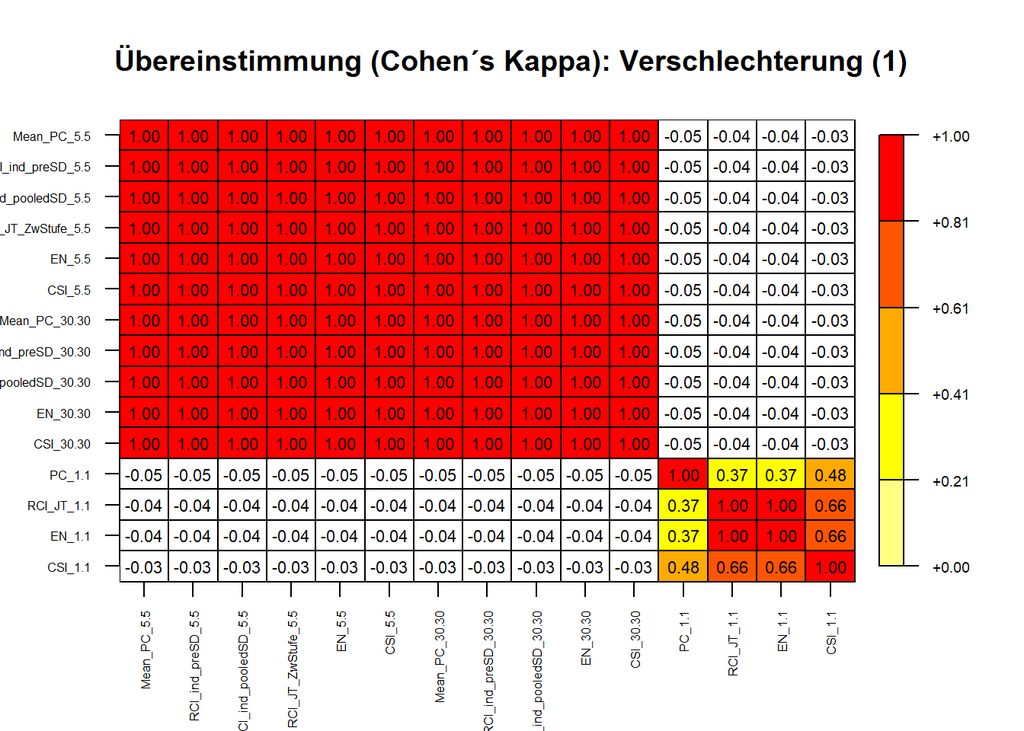

```r
### Cohen´s Kappa
Agreement = matrix(ncol = 15, nrow = 15, dimnames = list(rnames, rnames))

for (i in 1:nrow(Agreement)) {
  for (j in 1:ncol(Agreement)) {
    x = eval(parse(text = paste0("PP_Class$", names(PP_Class[,i])))) %>%
      recode_factor(., '1' = 1L)
    y = eval(parse(text = paste0("PP_Class$", names(PP_Class[,j])))) %>%
      recode_factor(., '1' = 1L)

    Agreement[i,j] = CohenKappa(x = x, y = y, useNA = "ifany")
  }
}

# mit plot.matrix::...
par(mar = c(5.1, 4.1, 4.1, 4.1)) # default c(5.1, 4.1, 4.1, 2.1)
plot(Agreement, col = heat.colors(n=5, rev=TRUE), fmt.cell = "%.2f", cex.axis = 0.5, cex = 0.7, las = 2,
     key = list(cex.axis=0.6), ann = FALSE, breaks = c(0, 0.21, 0.41, 0.61, 0.81, 1));
  title(main = "Übereinstimmung (Cohen´s Kappa): Verschlechterung (1)")
```

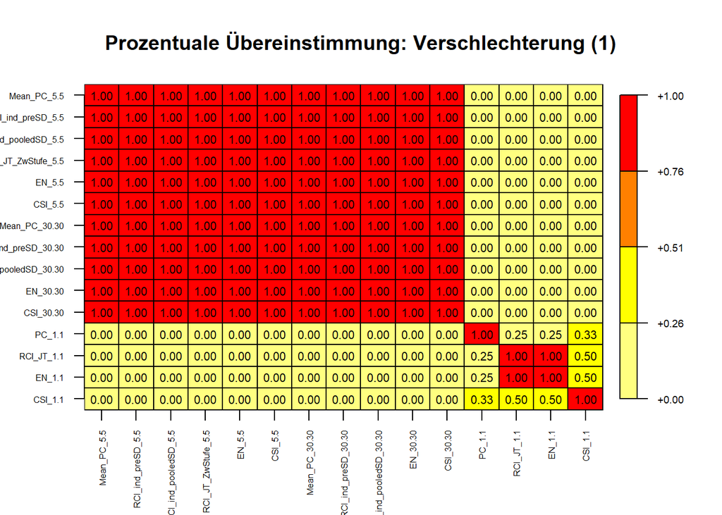

```r
### Prozentuale Übereinstimmung
Percentage_Agreement = matrix(ncol = 15, nrow = 15, dimnames = list(rnames, rnames))

for (i in 1:nrow(Percentage_Agreement)) {
  for (j in 1:ncol(Percentage_Agreement)) {
    x = eval(parse(text = paste0("PP_Class$", names(PP_Class[,i]))))
    y = eval(parse(text = paste0("PP_Class$", names(PP_Class[,j]))))

    Percentage_Agreement[i,j] = length(which(x == 1L & y == 1L)) /
      length(which(x == 1L | y == 1L))
  }
}

# mit plot.matrix::...
par(mar = c(5.1, 4.1, 4.1, 4.1)) # default c(5.1, 4.1, 4.1, 2.1)
plot(Percentage_Agreement, col = heat.colors(n=4, rev=TRUE), fmt.cell = "%.2f", cex.axis = 0.5, cex = 0.7, las = 2,
     key = list(cex.axis=0.6), ann = FALSE, breaks = c(0, 0.26, 0.51, 0.76, 1));
  title(main = "Prozentuale Übereinstimmung: Verschlechterung (1)")
```

## 1.15 Sensitivität und Spezifität der Klassifikationsmethoden

> Diagnostische Sensitivität und Spezifität einer “neuen” Testmethode im Vergleich zu einer “Goldstandard”-Testmethode:  
> Sensitivität = Wahrscheinlichkeit für ein richtig-positives Testergebnis  
> Spezifität = Wahrscheinlichkeit für ein richtig-negatives Testergebnis

$$Sensitivity = Recall = TPR = \frac{\sum{\text{True Positives}}} {\sum{\text{True Positives}} + \sum{\text{False Negatives}}} = \frac{tp}{tp + fn}$$

$$Specificity = Selectivity = TNR = \frac{\sum{\text{True Negatives}}} {\sum{\text{True Negatives}} + \sum{\text{False Positives}}} = \frac{tn}{tn + fp}$$

$$\textit{Geometric Mean of Sensitivity and Specificity} = \sqrt{Sensitivity \cdot Specificity}$$

$c$ = number of classes (i.e. 3: deteriorated; not changed; improved); $n_k$ = number of cases belonging to class $k$, with $k=1,...,c$; $n$ = total number of cases, with $n = \sum_{k=1}^{c} n_k$

> Sensitivität & Spezifität gegenüber Veränderung:  
> Evaluation der Veränderungs-Klassifikationen der Klassifikationsmethoden im Vergleich zur klinischen Signifikanz CSI (je 30 MZP) als “Goldstandard”:

```r
ClassEval = list()
for (i in 1:ncol(PP_Class)) {
  x = eval(parse(text = paste0("PP_Class$", colnames(PP_Class[,i]))))
  cm = confusionMatrix(x, reference = PP_Class$CSI_30.30,
                       dnn = c(paste0("PP_Class$", names(PP_Class[,i])), "CSI 30.30"), mode = "everything")
  cm$agreement = cm$overall[c("Accuracy","Kappa")]
  cm$senspez = cm$byClass %>%
    as_tibble() %>%
    select(Sensitivity, Specificity)

  cm$senspez_cwa = cm$senspez %>%
    summarise(across(.cols = everything(), .fns = geometric.mean, .names = "{.col}_cwa")) %>%
    mutate(GMean_SenSpez = geometric.mean(c(Sensitivity_cwa, Specificity_cwa)))

  ClassEval[[paste0(names(PP_Class[,i]))]] = cm[c("table","agreement","senspez","senspez_cwa")]
}

#save(ClassEval, file = "cor_07_k20/PP_ClassEval_n50.RData")
#load("cor_07_k20/PP_Class_n50.RData")

SenSpezSumm = tibble(Frequency = as.factor(c(rep("5.5", 6), rep("30.30", 5), rep("1.1", 4))),
                 Method = colnames(PP_Class),
                 Sens_imp = as.numeric(NA),
                 Sens_not = as.numeric(NA),
                 Sens_det = as.numeric(NA),
                 Spec_imp = as.numeric(NA),
                 Spec_not = as.numeric(NA),
                 Spec_det = as.numeric(NA),
                 Sensitivity_cwa = as.numeric(NA),
                 Specificity_cwa = as.numeric(NA),
                 SenSpec_mean = as.numeric(NA),
                 Accuracy_PercAgree = as.numeric(NA),
                 Kappa = as.numeric(NA))

for (i in 1:nrow(SenSpezSumm)) {
  SenSpezSumm[i,"Sens_imp"] = ClassEval[[i]][["senspez"]]$Sensitivity[1]
  SenSpezSumm[i,"Sens_not"] = ClassEval[[i]][["senspez"]]$Sensitivity[2]
  SenSpezSumm[i,"Sens_det"] = ClassEval[[i]][["senspez"]]$Sensitivity[3]

  SenSpezSumm[i,"Spec_imp"] = ClassEval[[i]][["senspez"]]$Specificity[1]
  SenSpezSumm[i,"Spec_not"] = ClassEval[[i]][["senspez"]]$Specificity[2]
  SenSpezSumm[i,"Spec_det"] = ClassEval[[i]][["senspez"]]$Specificity[3]

  SenSpezSumm[i,"Sensitivity_cwa"] = ClassEval[[i]][["senspez_cwa"]]$Sensitivity_cwa
  SenSpezSumm[i,"Specificity_cwa"] = ClassEval[[i]][["senspez_cwa"]]$Specificity_cwa
  SenSpezSumm[i,"SenSpec_mean"] = ClassEval[[i]][["senspez_cwa"]]$GMean_SenSpez

  SenSpezSumm[i,"Accuracy_PercAgree"] = ClassEval[[i]][["agreement"]][[1]]
  SenSpezSumm[i,"Kappa"] = ClassEval[[i]][["agreement"]][[2]]
}

#save(SenSpezSumm, file = "cor_07_k20/PP_SenSpezSumm_n50.RData")
#load("cor_07_k20/PP_SenSpezSumm_n50.RData")

SenSpezSumm %>%
  mutate(across(.cols = where(is.numeric), .fns = round, digits = 2)) %>%
  kable() %>%
  kable_styling(bootstrap_options = c("striped", "hover", "condensed"), full_width = FALSE)
```

| Frequency | Method | Sens_imp | Sens_not | Sens_det | Spec_imp | Spec_not | Spec_det | Sensitivity_cwa | Specificity_cwa | SenSpec_mean | Accuracy_PercAgree | Kappa |
| --- | --- | --- | --- | --- | --- | --- | --- | --- | --- | --- | --- | --- |
| 5.5 | Mean_PC_5.5 | 1.00 | 0.85 | 1 | 0.85 | 1.00 | 1.00 | 0.95 | 0.95 | 0.95 | 0.88 | 0.72 |
| 5.5 | RCI_ind_preSD_5.5 | 1.00 | 0.38 | 1 | 0.41 | 1.00 | 1.00 | 0.73 | 0.75 | 0.74 | 0.52 | 0.26 |
| 5.5 | RCI_ind_pooledSD_5.5 | 1.00 | 0.41 | 1 | 0.44 | 1.00 | 1.00 | 0.74 | 0.76 | 0.75 | 0.54 | 0.27 |
| 5.5 | RCI_JT_ZwStufe_5.5 | 1.00 | 0.49 | 1 | 0.51 | 1.00 | 1.00 | 0.79 | 0.80 | 0.79 | 0.60 | 0.33 |
| 5.5 | EN_5.5 | 1.00 | 0.26 | 1 | 0.29 | 1.00 | 1.00 | 0.64 | 0.66 | 0.65 | 0.42 | 0.18 |
| 5.5 | CSI_5.5 | 1.00 | 1.00 | 1 | 1.00 | 1.00 | 1.00 | 1.00 | 1.00 | 1.00 | 1.00 | 1.00 |
| 30.30 | Mean_PC_30.30 | 1.00 | 0.85 | 1 | 0.85 | 1.00 | 1.00 | 0.95 | 0.95 | 0.95 | 0.88 | 0.72 |
| 30.30 | RCI_ind_preSD_30.30 | 1.00 | 0.36 | 1 | 0.39 | 1.00 | 1.00 | 0.71 | 0.73 | 0.72 | 0.50 | 0.24 |
| 30.30 | RCI_ind_pooledSD_30.30 | 1.00 | 0.41 | 1 | 0.44 | 1.00 | 1.00 | 0.74 | 0.76 | 0.75 | 0.54 | 0.27 |
| 30.30 | EN_30.30 | 1.00 | 0.26 | 1 | 0.29 | 1.00 | 1.00 | 0.64 | 0.66 | 0.65 | 0.42 | 0.18 |
| 30.30 | CSI_30.30 | 1.00 | 1.00 | 1 | 1.00 | 1.00 | 1.00 | 1.00 | 1.00 | 1.00 | 1.00 | 1.00 |
| 1.1 | PC_1.1 | 0.56 | 0.69 | 0 | 0.78 | 0.45 | 0.94 | 0.00 | 0.69 | 0.00 | 0.64 | 0.17 |
| 1.1 | RCI_JT_1.1 | 0.67 | 0.54 | 0 | 0.61 | 0.55 | 0.96 | 0.00 | 0.68 | 0.00 | 0.54 | 0.10 |
| 1.1 | EN_1.1 | 0.67 | 0.41 | 0 | 0.49 | 0.55 | 0.96 | 0.00 | 0.63 | 0.00 | 0.44 | 0.02 |
| 1.1 | CSI_1.1 | 0.44 | 0.82 | 0 | 0.85 | 0.36 | 0.98 | 0.00 | 0.67 | 0.00 | 0.72 | 0.21 |

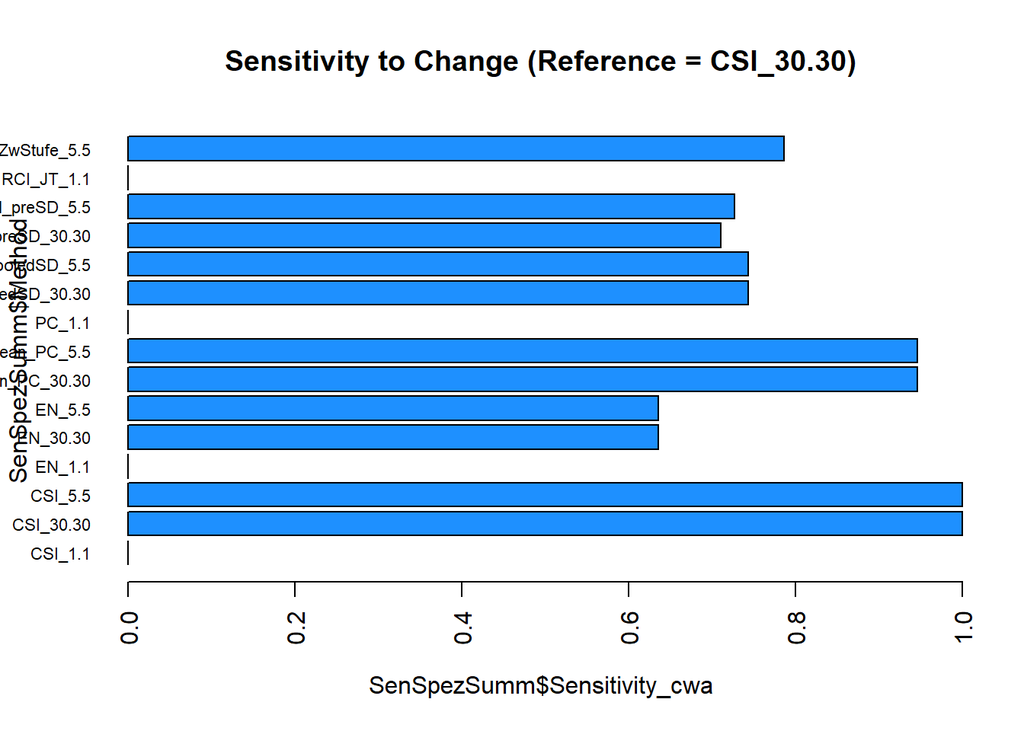

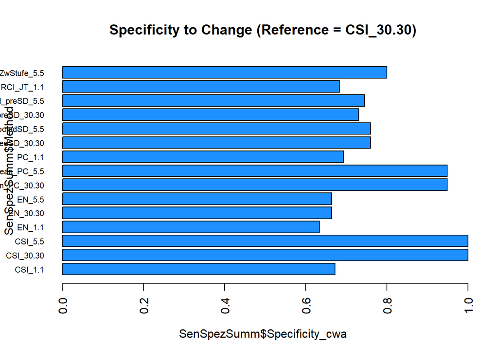

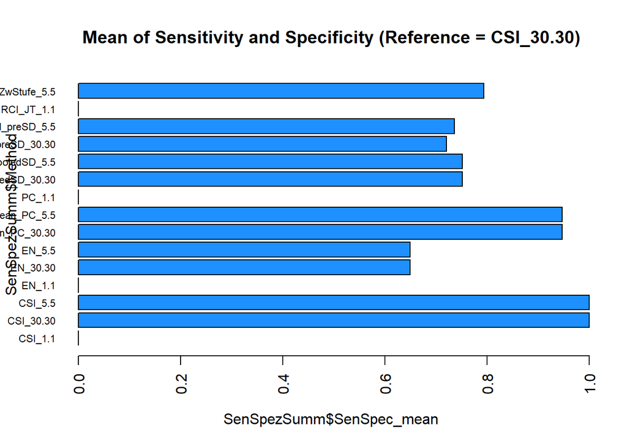

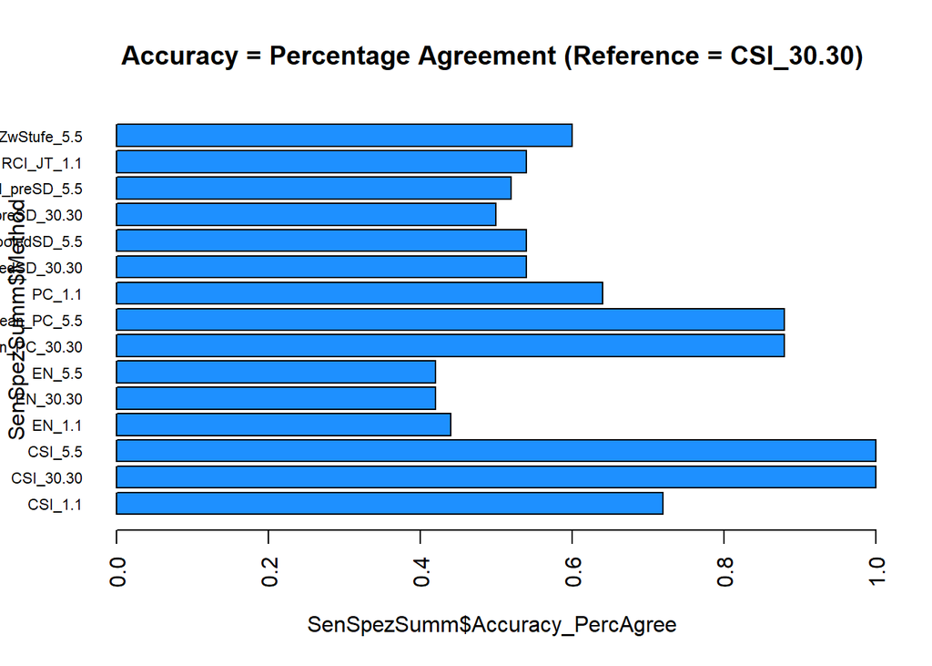

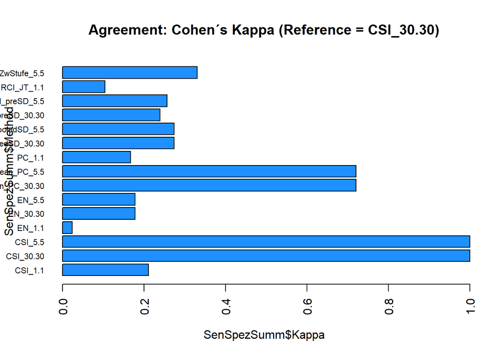

```r
graphics::barplot(SenSpezSumm$Sensitivity_cwa ~ SenSpezSumm$Method, col = "dodgerblue", las = 2, cex.names = 0.7,
                  horiz = TRUE, main = "Sensitivity to Change (Reference = CSI_30.30)")
graphics::barplot(SenSpezSumm$Specificity_cwa ~ SenSpezSumm$Method, col = "dodgerblue", las = 2, cex.names = 0.7,
                  horiz = TRUE, main = "Specificity to Change (Reference = CSI_30.30)")

graphics::barplot(SenSpezSumm$SenSpec_mean ~ SenSpezSumm$Method, col = "dodgerblue", las = 2, cex.names = 0.7,
                  horiz = TRUE, main = "Mean of Sensitivity and Specificity (Reference = CSI_30.30)")
graphics::barplot(SenSpezSumm$Accuracy_PercAgree ~ SenSpezSumm$Method, col = "dodgerblue", las = 2, cex.names = 0.7,
                  horiz = TRUE, main = "Accuracy = Percentage Agreement (Reference = CSI_30.30)")
graphics::barplot(SenSpezSumm$Kappa ~ SenSpezSumm$Method, col = "dodgerblue", las = 2, cex.names = 0.7,
                  horiz = TRUE, main = "Agreement: Cohen´s Kappa (Reference = CSI_30.30)")
```

## 1.16 Jackknife-Methode zum Resampling von Messzeitpunkten

> Statt wenige zufällige MZP-Kombinationen zu ziehen und diese dann mit den “wahren” Schätzwerten und Klassifikationen (= berechnet anhand der gesamten Intervalle mit je 30 MZP) zu vergleichen, sollen die empirische Verteilung der Parameter und somit der Schätzfehler über Resampling-Methoden wie Jackknife-Verfahren und Bootstrapping berechnet werden.

> Percentage Change (PC)

```r
###### PP_5.5
n = 5

Mean_PC = function(x, ID_df) {(1-((mean(ID_df[x,2])) / (mean(ID_df[x,1])))) * 100}

for (i in 1:nrow(PP_5.5)) {
  df = data.frame(PRE = as.numeric(PP_5.5[i,pre_5mzp]), POST = as.numeric(PP_5.5[i,post_5mzp]))

  PP_5.5[i,"Mean_PC_jse"] = jackknife(1:n, Mean_PC, df)$jack.se
  PP_5.5[i,"Mean_PC_jbias"] = jackknife(1:n, Mean_PC, df)$jack.bias
  message(i)
}

PP_5.5_Mean_PC_JK = PP_5.5 %>%
  select(ID, Mean_PC_jse, Mean_PC_jbias)
save(PP_5.5_Mean_PC_JK, file = "Jackknife/PP_5.5_Mean_PC_JK_k20_n50.RData")

###### PP_30.30
n = 30

Mean_PC = function(x, ID_df) {(1-((mean(ID_df[x,2])) / (mean(ID_df[x,1])))) * 100}

for (i in 1:nrow(PP_30.30)) {
  df = data.frame(PRE = as.numeric(PP_30.30[i,pre_30mzp]), POST = as.numeric(PP_30.30[i,post_30mzp]))

  PP_30.30[i,"Mean_PC_jse"] = jackknife(1:n, Mean_PC, df)$jack.se
  PP_30.30[i,"Mean_PC_jbias"] = jackknife(1:n, Mean_PC, df)$jack.bias
  message(i)
}

PP_30.30_Mean_PC_JK = PP_30.30 %>%
  select(ID, Mean_PC_jse, Mean_PC_jbias)
save(PP_30.30_Mean_PC_JK, file = "Jackknife/PP_30.30_Mean_PC_JK_k20_n50.RData")
```

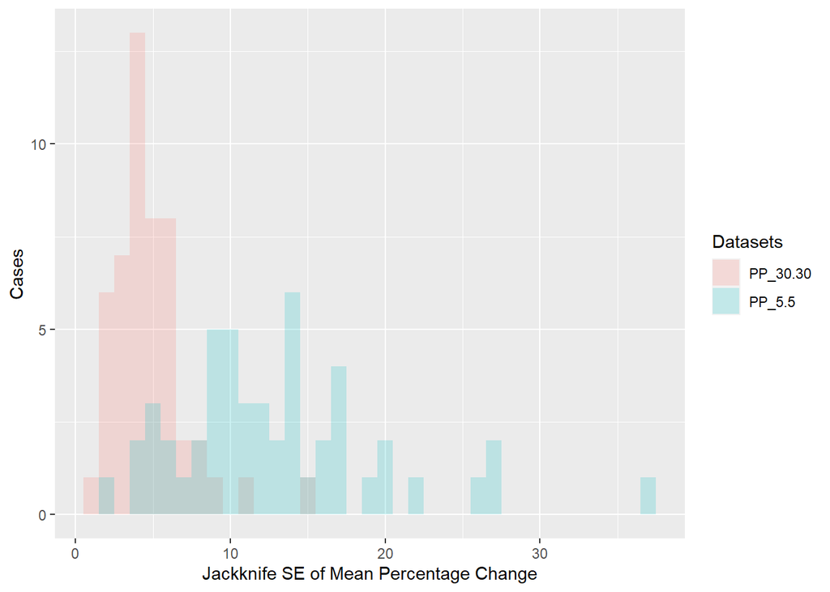

```r
load("Jackknife/PP_5.5_Mean_PC_JK_k20_n50.RData")
load("Jackknife/PP_30.30_Mean_PC_JK_k20_n50.RData")

PP_5.5 = full_join(PP_5.5, PP_5.5_Mean_PC_JK, by = "ID")
PP_30.30 = full_join(PP_30.30, PP_30.30_Mean_PC_JK, by = "ID")

temp = tibble(Jackknife_SE = c(PP_5.5$Mean_PC_jse, PP_30.30$Mean_PC_jse),
              Datasets = rep(c("PP_5.5", "PP_30.30"), each = length(PP_5.5$Mean_PC_jse)))

temp %>%
  ggplot(aes(x = Jackknife_SE, fill = Datasets)) +
    geom_histogram(alpha = 0.2, binwidth = 1, position = "identity") +
    labs(x = "Jackknife SE of Mean Percentage Change", y = "Cases")
```

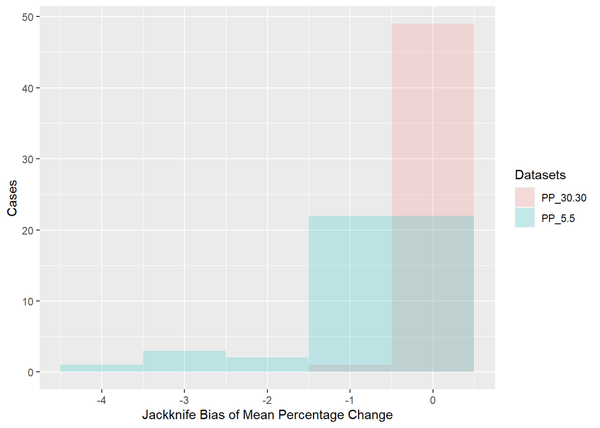

```r
#ggplot(temp, aes(x = Datasets, y = Jackknife_SE)) +
#  geom_boxplot(na.rm = TRUE) +
#  ggtitle("Jackknife SEs") +
#  xlab("Dataset")


temp = tibble(Jackknife_Bias = c(PP_5.5$Mean_PC_jbias, PP_30.30$Mean_PC_jbias),
              Datasets = rep(c("PP_5.5", "PP_30.30"), each = length(PP_5.5$Mean_PC_jbias)))

temp %>%
  ggplot(aes(x = Jackknife_Bias, fill = Datasets)) +
    geom_histogram(alpha = 0.2, binwidth = 1, position = "identity") +
    labs(x = "Jackknife Bias of Mean Percentage Change", y = "Cases")
```

```r
#ggplot(temp, aes(x = Datasets, y = Jackknife_Bias)) +
#  geom_boxplot(na.rm = TRUE) +
#  ggtitle("Jackknife Biases") +
#  xlab("Dataset")
```

> RCI(ind) nur mit SD aus dem individuellen Pre-Intervall

```r
###### PP_5.5
n = 5

RCI_ind_preSD = function(x, ID_df) {(mean(ID_df[x,2]) - mean(ID_df[x,1])) /
    sqrt(2 * (sd(ID_df[x,1]) * sqrt(1 - PP_5.5_Alpha))^2)}

for (i in 1:nrow(PP_5.5)) {
  df = data.frame(PRE = as.numeric(PP_5.5[i,pre_5mzp]), POST = as.numeric(PP_5.5[i,post_5mzp]))

  PP_5.5[i,"RCI_ind_preSD_jse"] = jackknife(1:n, RCI_ind_preSD, df)$jack.se
  PP_5.5[i,"RCI_ind_preSD_jbias"] = jackknife(1:n, RCI_ind_preSD, df)$jack.bias
  message(i)
}

PP_5.5_RCI_ind_preSD_JK = PP_5.5 %>%
  select(ID, RCI_ind_preSD_jse, RCI_ind_preSD_jbias)
save(PP_5.5_RCI_ind_preSD_JK, file = "Jackknife/PP_5.5_RCI_ind_preSD_JK_k20_n50.RData")

###### PP_30.30
n = 30

RCI_ind_preSD = function(x, ID_df) {(mean(ID_df[x,2]) - mean(ID_df[x,1])) /
    sqrt(2 * (sd(ID_df[x,1]) * sqrt(1 - PP_5.5_Alpha))^2)}

for (i in 1:nrow(PP_30.30)) {
  df = data.frame(PRE = as.numeric(PP_30.30[i,pre_30mzp]), POST = as.numeric(PP_30.30[i,post_30mzp]))

  PP_30.30[i,"RCI_ind_preSD_jse"] = jackknife(1:n, RCI_ind_preSD, df)$jack.se
  PP_30.30[i,"RCI_ind_preSD_jbias"] = jackknife(1:n, RCI_ind_preSD, df)$jack.bias
  message(i)
}

PP_30.30_RCI_ind_preSD_JK = PP_30.30 %>%
  select(ID, RCI_ind_preSD_jse, RCI_ind_preSD_jbias)
save(PP_30.30_RCI_ind_preSD_JK, file = "Jackknife/PP_30.30_RCI_ind_preSD_JK_k20_n50.RData")
```

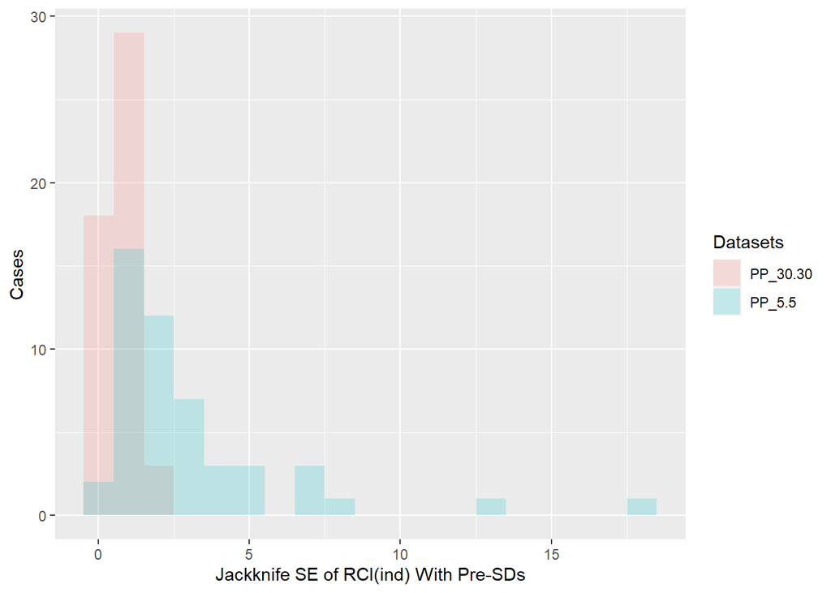

```r
load("Jackknife/PP_5.5_RCI_ind_preSD_JK_k20_n50.RData")
load("Jackknife/PP_30.30_RCI_ind_preSD_JK_k20_n50.RData")

PP_5.5 = full_join(PP_5.5, PP_5.5_RCI_ind_preSD_JK, by = "ID")
PP_30.30 = full_join(PP_30.30, PP_30.30_RCI_ind_preSD_JK, by = "ID")

temp = tibble(Jackknife_SE = c(PP_5.5$RCI_ind_preSD_jse, PP_30.30$RCI_ind_preSD_jse),
              Datasets = rep(c("PP_5.5", "PP_30.30"), each = length(PP_5.5$RCI_ind_preSD_jse)))

temp %>%
  ggplot(aes(x = Jackknife_SE, fill = Datasets)) +
    geom_histogram(alpha = 0.2, binwidth = 1, position = "identity") +
    labs(x = "Jackknife SE of RCI(ind) With Pre-SDs", y = "Cases")
```

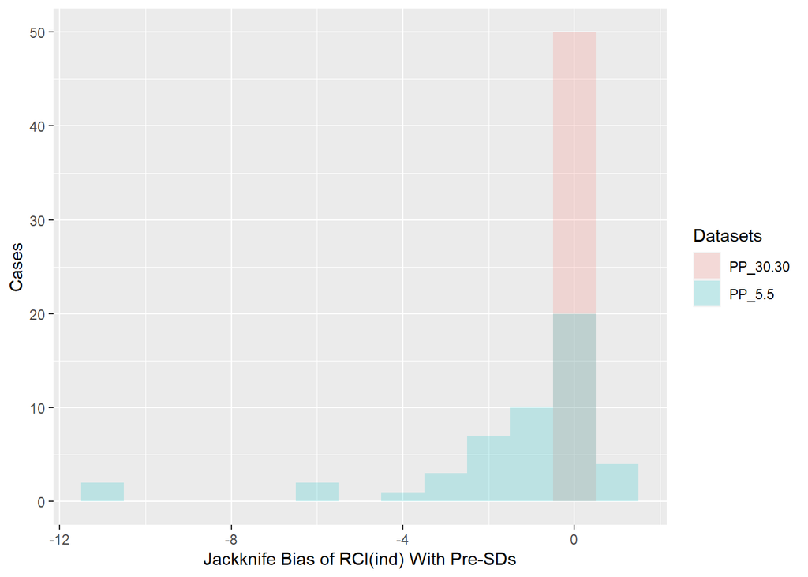

```r
#ggplot(temp, aes(x = Datasets, y = Jackknife_SE)) +
#  geom_boxplot(na.rm = TRUE) +
#  ggtitle("Jackknife SEs") +
#  xlab("Dataset")


temp = tibble(Jackknife_Bias = c(PP_5.5$RCI_ind_preSD_jbias, PP_30.30$RCI_ind_preSD_jbias),
              Datasets = rep(c("PP_5.5", "PP_30.30"), each = length(PP_5.5$RCI_ind_preSD_jbias)))

temp %>%
  ggplot(aes(x = Jackknife_Bias, fill = Datasets)) +
    geom_histogram(alpha = 0.2, binwidth = 1, position = "identity") +
    labs(x = "Jackknife Bias of RCI(ind) With Pre-SDs", y = "Cases")
```

```r
#ggplot(temp, aes(x = Datasets, y = Jackknife_Bias)) +
#  geom_boxplot(na.rm = TRUE) +
#  ggtitle("Jackknife Biases") +
#  xlab("Dataset")
```

> RCI(ind) mit pooled SDs aus beiden individuellen Intervallen

```r
###### PP_5.5
n = 5

RCI_ind_pooledSD = function(x, ID_df) {(mean(ID_df[x,2]) - mean(ID_df[x,1])) /
    sqrt((sd(ID_df[x,1])^ 2 + sd(ID_df[x,2])^ 2) * (1 - PP_5.5_Alpha))}

for (i in 1:nrow(PP_5.5)) {
  df = data.frame(PRE = as.numeric(PP_5.5[i,pre_5mzp]), POST = as.numeric(PP_5.5[i,post_5mzp]))

  PP_5.5[i,"RCI_ind_pooledSD_jse"] = jackknife(1:n, RCI_ind_pooledSD, df)$jack.se
  PP_5.5[i,"RCI_ind_pooledSD_jbias"] = jackknife(1:n, RCI_ind_pooledSD, df)$jack.bias
  message(i)
}

PP_5.5_RCI_ind_pooledSD_JK = PP_5.5 %>%
  select(ID, RCI_ind_pooledSD_jse, RCI_ind_pooledSD_jbias)
save(PP_5.5_RCI_ind_pooledSD_JK, file = "Jackknife/PP_5.5_RCI_ind_pooledSD_JK_k20_n50.RData")

###### PP_30.30
n = 30

RCI_ind_pooledSD = function(x, ID_df) {(mean(ID_df[x,2]) - mean(ID_df[x,1])) /
    sqrt((sd(ID_df[x,1])^ 2 + sd(ID_df[x,2])^ 2) * (1 - PP_5.5_Alpha))}

for (i in 1:nrow(PP_30.30)) {
  df = data.frame(PRE = as.numeric(PP_30.30[i,pre_30mzp]), POST = as.numeric(PP_30.30[i,post_30mzp]))

  PP_30.30[i,"RCI_ind_pooledSD_jse"] = jackknife(1:n, RCI_ind_pooledSD, df)$jack.se
  PP_30.30[i,"RCI_ind_pooledSD_jbias"] = jackknife(1:n, RCI_ind_pooledSD, df)$jack.bias
  message(i)
}

PP_30.30_RCI_ind_pooledSD_JK = PP_30.30 %>%
  select(ID, RCI_ind_pooledSD_jse, RCI_ind_pooledSD_jbias)
save(PP_30.30_RCI_ind_pooledSD_JK, file = "Jackknife/PP_30.30_RCI_ind_pooledSD_JK_k20_n50.RData")
```

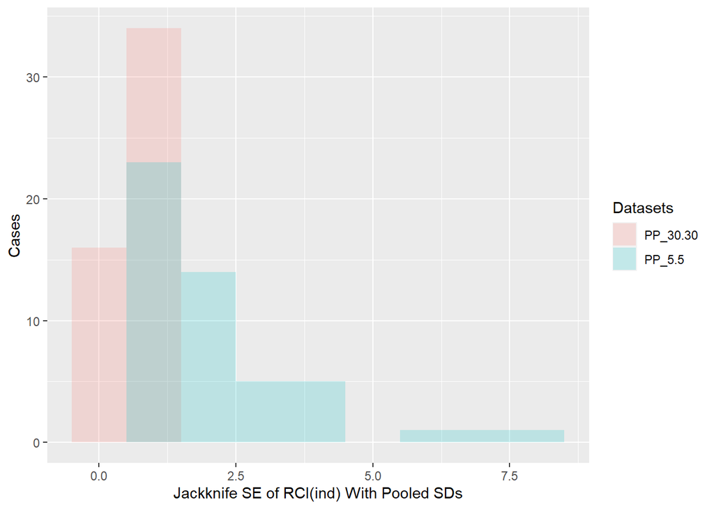

```r
load("Jackknife/PP_5.5_RCI_ind_pooledSD_JK_k20_n50.RData")
load("Jackknife/PP_30.30_RCI_ind_pooledSD_JK_k20_n50.RData")

PP_5.5 = full_join(PP_5.5, PP_5.5_RCI_ind_pooledSD_JK, by = "ID")
PP_30.30 = full_join(PP_30.30, PP_30.30_RCI_ind_pooledSD_JK, by = "ID")

temp = tibble(Jackknife_SE = c(PP_5.5$RCI_ind_pooledSD_jse, PP_30.30$RCI_ind_pooledSD_jse),
              Datasets = rep(c("PP_5.5", "PP_30.30"), each = length(PP_5.5$RCI_ind_pooledSD_jse)))

temp %>%
  ggplot(aes(x = Jackknife_SE, fill = Datasets)) +
    geom_histogram(alpha = 0.2, binwidth = 1, position = "identity") +
    labs(x = "Jackknife SE of RCI(ind) With Pooled SDs", y = "Cases")
```

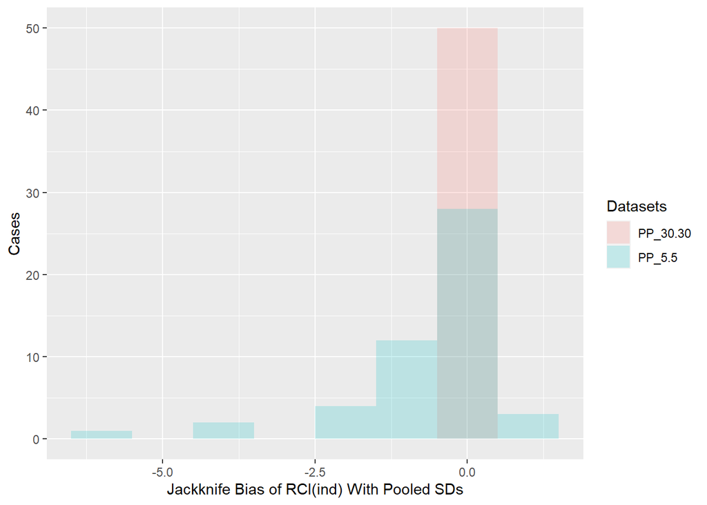

```r
#ggplot(temp, aes(x = Datasets, y = Jackknife_SE)) +
#  geom_boxplot(na.rm = TRUE) +
#  ggtitle("Jackknife SEs") +
#  xlab("Dataset")


temp = tibble(Jackknife_Bias = c(PP_5.5$RCI_ind_pooledSD_jbias, PP_30.30$RCI_ind_pooledSD_jbias),
              Datasets = rep(c("PP_5.5", "PP_30.30"), each = length(PP_5.5$RCI_ind_pooledSD_jbias)))

temp %>%
  ggplot(aes(x = Jackknife_Bias, fill = Datasets)) +
    geom_histogram(alpha = 0.2, binwidth = 1, position = "identity") +
    labs(x = "Jackknife Bias of RCI(ind) With Pooled SDs", y = "Cases")
```

```r
#ggplot(temp, aes(x = Datasets, y = Jackknife_Bias)) +
#  geom_boxplot(na.rm = TRUE) +
#  ggtitle("Jackknife Biases") +
#  xlab("Dataset")
```